# Apuntes para el curso de Cálculo Diferencial

Carlos Ernesto Martinez

2023-08-12

# Presentación

En esta página encontrarás ejercicios adicionales a los vistos en clase

## Información personal y redes sociales

- ```
  Página
  personal
  ```

- [`Twitter`](https://twitter.com/carlosmroder)
- [`Linkedin`](https://www.linkedin.com/in/carlos-martinez-r/)

Puedes descargar el archivo PDF de los apuntes [aquí](https://github.com/ProfTodoMundo/NotasCalculoDiferencial/blob/PrincipalCD/docs/ApuntesCalculo.pdf).

[figure not shown]

Acceder al documento

# Programa de Estudios de Cálculo Diferencial

## Propósitos generales: Al terminar el curso, el alumno:

1. Podrá plantear funciones, reales de variable real, a partir de modelos sencillos provenientes de otras disciplinas científicas o ingenieriles. Podrá decidir si son continuas o diferenciables, manejando con soltura los conceptos de continuidad, límites y derivada.
2. Conocerá y usará con soltura los métodos del cálculo diferencial, pudiendo derivar, con la definición al principio y luego con técnicas adecuadas, varios tipos de funciones: polinomiales, racionales, radicales, trigonométricas y composiciones de ellas.
3. Podrá graficar con precisión varios tipos de funciones, indicando puntos importantes en la gráfica incluyendo intervalos donde la función es monótona o tiene cierta concavidad.
4. Conocerá los conceptos de máximo y mínimo (local y global) de funciones definidas en intervalos de reales y podrá usar los criterios de la primera y segunda derivada para decidir si un punto dado es máximo, mínimo o punto de inflexión de una función.
5. Podrá plantear y resolver problemas de optimización (máximos y mínimos) o razón de cambio partiendo de situaciones geométricas o de modelos provenientes de otras disciplinas.
6. Podrá usar algún tipo de programa de cómputo adecuado para graficar algunas funciones y visualizar aspectos geométricos de las mismas.
7. Podrá aproximar valores de funciones usando diferenciales y sabrá usar la regla de L’Hôpital para calcular límites indeterminados.

### Seriación: NO Asignaturas Previas:

- Paralela: Álgebra y Geometría Analítica
- Posteriores: Álgebra Lineal, Cálculo Integral, Cálculo Vectorial, Ecuaciones Diferenciales Ordinarias, Ecuaciones Diferenciales Parciales, Métodos Numéricos, Estadística y Probabilidad.

### Requerimientos para cursar la asignatura

**Conocimientos:** Dominio de factorización, operaciones y simplificación de expresiones algebráicas, Teorema de Pitágoras, resolución de sistemas de ecuaciones lineales de 2x2, resolución de ecuaciones lineales y cuadráticas, proporciones.

**Habilidades:** abstracción (poder pasar de español al lenguaje simbólico y viceversa) y poder resolver problemas sencillos de álgebra utilizando los conocimientos arriba mencionados.

**Perfil deseable del profesor:** Licenciatura o posgrado en Matemáticas o carreras afines (Matemáticas aplicadas, Física, Actuaría, Ingeniería). Que esté dispuesto a trabajar en la educación centrada en el aprendizaje de los alumnos. Que tenga experiencia docente y habilidad para conducir los procesos de aprendizaje.

**Academia responsable del programa:** Matemáticas.

**Elaborado por:** Manuel Fernández Villanueva y José Juan Hernández.

## Temario de asignatura

Nombre de la asignatura: Cálculo Diferencial.

### Objetivo(s) general(es) de la asignatura:

Al terminar el curso, el alumno:

1. Podrá plantear funciones, reales de variable real, a partir de modelos sencillos provenientes de otras disciplinas científicas o ingenieriles. Podrá decidir si son continuas o diferenciables, manejando con soltura los conceptos de continuidad, límites y derivada.
2. Conocerá y usará con soltura los métodos del cálculo diferencial, pudiendo derivar, con la definición al principio y luego con técnicas adecuadas, varios tipos de funciones: polinomiales, racionales, radicales, trigonométricas y composiciones de ellas.
3. Podrá graficar con precisión varios tipos de funciones, indicando puntos importantes en la gráfica incluyendo intervalos donde la función es monótona o tiene cierta concavidad.
4. Conocerá los conceptos de máximo y mínimo (local y global) de funciones definidas en intervalos de reales y podrá usar los criterios de la primera y segunda derivada para decidir si un punto dado es máximo, mínimo o punto de inflexión de una función.
5. Podrá plantear y resolver problemas de optimización (máximos y mínimos) o razón de cambio partiendo de situaciones geométricas o de modelos provenientes de otras disciplinas.
6. Podrá usar algún tipo de programa de cómputo adecuado para graficar algunas funciones y visualizar aspectos geométricos de las mismas.
7. Podrá aproximar valores de funciones usando diferenciales y sabrá usar la regla de L’Hôpital para calcular límites indeterminados.

## Temas y subtemas:

### 1. Funciones.

1.1 La noción de función a partir de modelos sencillos tomados de varias disciplinas (Física, Biología, Química, Ingenierías, Economía). Ejemplos de funciones obtenidas como fórmulas al plantear problemas.

1.2 Breve introducción a R. Desigualdades, intervalos, valor absoluto.

1.3 Dominio e imagen. Gráfica de una función. Operaciones con funciones (suma, resta, producto y cociente).

1.4 Algunos tipos especiales de funciones: lineales, cuadráticas, polinomios y racionales. Funciones que se definen con radicales. Funciones definidas por partes. Funciones exponenciales, logarítmicas y trigonométricas.

1.5 Composición de funciones.

1.6 Funciones inyectivas, suprayectivas y biyectivas. Funciones inversas.

### 2. Límites y continuidad.

2.1 Movimiento rectilíneo. La gráfica posición-tiempo. La noción de velocidad media. La velocidad instantánea como motivación para el concepto de límite.

2.2 Idea intuitiva y definición de límite.

2.3 Operaciones con límites. Cálculo de límites.

2.4 Límites laterales.

2.5 Límites infinitos.

2.6 Límites cuando la variable independiente tiende a infinito.

2.7 Continuidad.

### 3. Derivadas.

3.1 Razón de cambio. La velocidad como una razón de cambio. La velocidad instantánea como motivación para el concepto de derivada.

3.2 Definición de derivada. Interpretación geométrica. Definición de tangente a una curva en un punto.

3.3 Derivadas de las funciones elementales.

3.4 Derivadas de sumas, restas, productos y cocientes.

3.5 Aproximaciones lineales. Diferencial.

3.5 Regla de la cadena. Derivada de las funciones inversas. Derivación implícita.

3.6 La aceleración como razón de cambio de la velocidad. Derivadas de orden superior.

### 4. Aplicaciones de la derivada.

4.1 La derivada y el crecimiento o decrecimiento de una función. 4.2 Máximos y mínimos locales y globales. El criterio de la primera derivada. 4.3 Concavidad, puntos de inflexión y el criterio de la segunda derivada. 4.4 Problemas de optimizacion. 4.5 Razones de cambio relacionadas. Aplicaciones 4.6 Graficación. 4.7 La regla de L’Hôpital.

## Metodología de la enseñanza

Los conceptos y métodos deberán motivarse ampliamente, de ser posible usando ejemplos sencillos provenientes de otras disciplinas, en particular de la mecánica del movimiento rectilíneo. Los teoremas que sean necesarios se discutirán ampliamente, bosquejando su demostración enfatizando las ideas involucradas (de ser posible, con gráficas o ejemplos de la Física manejados en forma intuitiva). Cuando el profesor lo considere adecuado, podrá auxiliarse de algún programa de cómputo para graficar funciones complicadas o para visualizar algunos conceptos (por ejemplo, la derivada como pendiente de la recta tangente a la gráfica de una función). El curso consiste de tres sesiones semanales en salón conducidas por el profesor y una sesión de laboratorio donde se formarán equipos de alumnos para discutir problemas o ejercicios de los temas vistos en las clases previas. Ocasionalmente el laboratorio podrá ser un laboratorio de cómputo.

## Modalidades de evaluación de la asignatura:

Diagnóstica, formativa y para la certificación.

## Bibliografía:

- Larson, Hostetler, Edwards, Cálculo I, Pirámide, 2002, 7ª .
- Hughes-Hallett, Gleason et al., Cálculo aplicado, CECSA, 2003, 1ª.
- Leithold, El cálculo, Oxford, 2003, 7ª.
- Thomas, Finney, Cálculo. Una variable, Adison Wesley Longman, 1999, 9ª.
- Stewart, Cálculo. Trascendentes tempranas, Thomson, 2002, 4ª.
- Swokowski, Cálculo con Geometría Analítica, Iberoamérica, 1989, 2ª.

# 1. Pre-requisitos

## Ecuaciones de la forma $ax+b=cx+d$

1. Resuelve las siguientes ecuaciones
   1. $2x + 3 = 4x - 1$
   2. $-5x - 2 = 3x + 7$
   3. $8x + 6 = -2x - 4$
   4. $-4x + 9 = 2x + 1$
   5. $6x - 5 = -3x + 2$
   6. $-7x + 10 = 5x - 8$
   7. $9x - 12 = -6x + 15$
   8. $-3x + 4 = 7x + 2$
   9. $11x + 13 = -9x - 15$
   10. $-2x - 1 = 4x + 6$
   11. $12x - 8 = -10x + 14$
   12. $-6x + 7 = 8x - 9$
   13. $5x - 3 = -7x + 11$
   14. $-13x + 16 = 15x - 18$
   15. $14x + 20 = -16x - 22$
2. Resuelve las siguientes ecuaciones de la forma $\frac{a}{b}x+\frac{c}{d}=\frac{e}{f}$
   1. $\frac{2}{3}x - \frac{5}{4} = \frac{7}{6}$
   2. $-\frac{1}{2}x + \frac{3}{5} = -\frac{4}{7}$
   3. $\frac{7}{8}x + \frac{9}{10} = -\frac{11}{12}$
   4. $-\frac{3}{4}x - \frac{6}{7} = \frac{9}{10}$
   5. $\frac{4}{5}x - \frac{2}{3} = -\frac{1}{6}$
   6. $-\frac{5}{6}x + \frac{8}{9} = \frac{11}{12}$
   7. $\frac{6}{7}x + \frac{1}{2} = -\frac{4}{9}$
   8. $-\frac{9}{10}x - \frac{7}{8} = \frac{5}{6}$
   9. $\frac{11}{12}x + \frac{10}{11} = -\frac{9}{10}$
   10. $-\frac{2}{3}x - \frac{5}{6} = \frac{7}{8}$
   11. $\frac{3}{4}x - \frac{4}{5} = -\frac{1}{2}$
   12. $-\frac{5}{6}x + \frac{7}{8} = \frac{9}{10}$
   13. $\frac{6}{7}x + \frac{8}{9} = -\frac{10}{11}$
   14. $-\frac{4}{5}x - \frac{3}{4} = \frac{1}{2}$
   15. $\frac{9}{10}x + \frac{1}{3} = -\frac{5}{6}$
3. Resuelve las siguientes ecuaciones de la forma $\frac{a}{b}x+\frac{c}{d}=\frac{e}{f}x+\frac{g}{h}$
   1. $\frac{3}{5}x - \frac{4}{7} = \frac{8}{9}x + \frac{2}{3}$
   2. $-\frac{7}{8}x + \frac{6}{11} = -\frac{5}{6}x - \frac{3}{4}$
   3. $\frac{9}{10}x + \frac{7}{12} = -\frac{4}{5}x + \frac{1}{3}$
   4. $-\frac{5}{6}x - \frac{2}{3} = \frac{3}{4}x - \frac{1}{2}$
   5. $\frac{4}{7}x - \frac{5}{8} = -\frac{6}{9}x + \frac{7}{10}$
   6. $-\frac{11}{12}x + \frac{8}{9} = \frac{7}{10}x - \frac{6}{7}$
   7. $\frac{2}{3}x + \frac{9}{11} = -\frac{1}{2}x + \frac{4}{5}$
   8. $-\frac{7}{8}x - \frac{6}{7} = \frac{5}{6}x - \frac{3}{5}$
   9. $\frac{5}{6}x + \frac{4}{5} = -\frac{3}{4}x + \frac{2}{3}$
   10. $-\frac{1}{2}x - \frac{3}{4} = \frac{5}{6}x - \frac{7}{8}$
   11. $\frac{9}{10}x - \frac{8}{9} = -\frac{7}{8}x + \frac{6}{7}$
   12. $-\frac{4}{5}x + \frac{3}{4} = \frac{2}{3}x - \frac{1}{2}$
   13. $\frac{1}{3}x + \frac{5}{7} = -\frac{9}{10}x + \frac{8}{9}$
   14. $-\frac{6}{7}x - \frac{4}{5} = \frac{2}{3}x - \frac{1}{2}$
   15. $\frac{7}{8}x + \frac{6}{11} = -\frac{5}{6}x + \frac{3}{4}$
4. Resuelve las siguientes ecuaciones de la forma $\frac{a}{b}+\left\{\frac{c}{d}[\frac{e}{f}(\frac{i}{j}+\frac{k}{l})+\frac{g}{h}(\frac{m}{n}+\frac{o}{p})+\frac{q}{r}] \right\}=\frac{s}{t}(\frac{u}{v}+\frac{w}{x})+\frac{y}{z}$
   1. $\frac{3}{4}+\left\{\frac{2}{5}[\frac{5}{6}(\frac{2}{3}x+\frac{4}{5})+\frac{7}{8}(\frac{3}{4}x+\frac{5}{6})+\frac{1}{2}]\right\}=\frac{9}{10}(\frac{4}{5}x+\frac{6}{7})+\frac{1}{3}+\frac{4}{5}x$
   2. $\frac{5}{6}-\left\{-\frac{3}{4}[-\frac{4}{5}(-\frac{2}{3}x-\frac{5}{6})-\frac{6}{7}(-\frac{3}{4}x+\frac{7}{8})-\frac{1}{2}]\right\}=-\frac{8}{9}(-\frac{4}{5}x+\frac{9}{10})-\frac{1}{4}-\frac{5}{6}x$
   3. $-\frac{4}{5}+\left\{\frac{7}{8}[\frac{2}{3}(\frac{5}{6}x-\frac{3}{4})+\frac{4}{5}(\frac{6}{7}x+\frac{8}{9})-\frac{1}{2}]\right\}=\frac{3}{4}(\frac{4}{5}x+\frac{7}{8})-\frac{5}{6}-\frac{2}{3}x$
   4. $\frac{3}{4}-\left\{\frac{6}{7}[\frac{5}{6}(\frac{3}{4}x-\frac{4}{5})+\frac{7}{8}(\frac{2}{3}x-\frac{5}{6})-\frac{1}{2}]\right\}=\frac{9}{10}(\frac{4}{5}x+\frac{6}{7})-\frac{1}{3}+\frac{4}{5}x$
   5. $-\frac{6}{7}+\left\{\frac{2}{3}[-\frac{4}{5}(\frac{5}{6}x+\frac{6}{7})-\frac{7}{8}(\frac{3}{4}x+\frac{4}{5})-\frac{1}{2}]\right\}=-\frac{8}{9}(\frac{2}{3}x-\frac{6}{7})-\frac{1}{4}-\frac{3}{5}x$
   6. $\frac{7}{8}-\left\{\frac{5}{6}[\frac{3}{4}(\frac{2}{3}x-\frac{5}{6})-\frac{6}{7}(-\frac{5}{6}x+\frac{3}{4})-\frac{1}{2}]\right\}=-\frac{4}{5}(\frac{3}{4}x+\frac{8}{9})-\frac{2}{3}+\frac{7}{8}x$
   7. $-\frac{4}{5}+\left\{\frac{7}{8}[\frac{5}{6}(\frac{3}{4}x-\frac{2}{3})+\frac{4}{5}(\frac{6}{7}x-\frac{5}{6})-\frac{1}{2}]\right\}=\frac{3}{4}(\frac{2}{3}x+\frac{7}{8})-\frac{1}{6}-\frac{2}{5}x$
   8. $\frac{3}{4}-\left\{\frac{2}{3}[\frac{5}{6}(\frac{4}{5}x-\frac{7}{8})+\frac{7}{8}(\frac{5}{6}x+\frac{4}{5})-\frac{1}{2}]\right\}=\frac{9}{10}(\frac{5}{6}x+\frac{6}{7})+\frac{1}{4}-\frac{4}{5}x$
   9. $-\frac{6}{7}+\left\{\frac{4}{5}[\frac{2}{3}(\frac{5}{6}x+\frac{7}{8})+\frac{7}{8}(\frac{4}{5}x-\frac{2}{3})-\frac{1}{2}]\right\}=\frac{8}{9}(\frac{3}{4}x-\frac{6}{7})-\frac{1}{5}-\frac{5}{6}x$
   10. $\frac{7}{8}+\left\{-\frac{5}{6}[\frac{3}{4}(\frac{4}{5}x-\frac{6}{7})+\frac{6}{7}(\frac{5}{6}x+\frac{3}{4})-\frac{1}{2}]\right\}=-\frac{4}{5}(\frac{4}{5}x+\frac{5}{6})-\frac{2}{3}+\frac{7}{8}x$
   11. $-\frac{4}{5}-\left\{\frac{7}{8}[\frac{2}{3}(-\frac{5}{6}x-\frac{7}{8})+\frac{4}{5}(\frac{6}{7}x-\frac{5}{6})-\frac{1}{2}]\right\}=-\frac{3}{4}(\frac{5}{6}x-\frac{7}{8})-\frac{1}{7}-\frac{6}{7}x$
   12. $-\frac{3}{4}+\left\{-\frac{2}{3}[\frac{5}{6}(\frac{4}{5}x+\frac{7}{8})+\frac{7}{8}(\frac{5}{6}x-\frac{4}{5})-\frac{1}{2}]\right\}=\frac{9}{10}(-\frac{5}{6}x+\frac{4}{5})-\frac{1}{8}+\frac{7}{8}x$
   13. $-\frac{6}{7}-\left\{\frac{4}{5}[\frac{2}{3}(\frac{5}{6}x-\frac{2}{3})+\frac{7}{8}(\frac{4}{5}x+\frac{7}{8})-\frac{1}{2}]\right\}=-\frac{8}{9}(\frac{6}{7}x+\frac{4}{5})-\frac{1}{9}-\frac{8}{9}x$
   14. $-\frac{7}{8}+\left\{\frac{5}{6}[\frac{3}{4}(-\frac{4}{5}x-\frac{6}{7})-\frac{6}{7}(\frac{5}{6}x+\frac{4}{5})-\frac{1}{2}]\right\}=-\frac{4}{5}(\frac{4}{5}x+\frac{6}{7})+\frac{2}{3}-\frac{7}{8}x$
   15. $-\frac{4}{5}+\left\{\frac{7}{8}[-\frac{2}{3}(\frac{5}{6}x-\frac{7}{8})-\frac{4}{5}(\frac{6}{7}x+\frac{2}{3})-\frac{1}{2}]\right\}=-\frac{3}{4}(\frac{5}{6}x+\frac{7}{8})-\frac{1}{10}-\frac{2}{3}x$
5. Resuelve los ejercicios de la forma $\frac{\frac{a}{b}x+\frac{c}{d}}{\frac{e}{f}}+\frac{g}{h}=\frac{\frac{i}{j}x+\frac{k}{l}}{m}$
   1. $\frac{-\frac{3}{4}x+\frac{5}{6}}{-\frac{7}{8}}+\frac{1}{2}=-\frac{\frac{9}{10}x+\frac{11}{12}}{13}$
   2. $-\frac{-\frac{2}{3}x+\frac{4}{5}}{-\frac{6}{7}}+\frac{1}{2}=-\frac{\frac{8}{9}x+\frac{10}{11}}{12}$
   3. $\frac{\frac{5}{6}x-\frac{7}{8}}{\frac{9}{10}}-\frac{3}{4}=-\frac{\frac{11}{12}x+\frac{13}{14}}{15}$
   4. $\frac{\frac{7}{8}x+\frac{9}{10}}{\frac{11}{12}}+\frac{5}{6}=-\frac{\frac{15}{16}x+\frac{17}{18}}{19}$
   5. $\frac{\frac{4}{5}x+\frac{6}{7}}{\frac{8}{9}}+\frac{2}{3}=\frac{\frac{10}{11}x+\frac{12}{13}}{14}$
   6. $\frac{\frac{6}{7}x-\frac{8}{9}}{\frac{10}{11}}+\frac{3}{4}=\frac{\frac{14}{15}x+\frac{16}{17}}{18}$
   7. $-\frac{\frac{1}{2}x+\frac{3}{4}}{\frac{5}{6}}-\frac{4}{5}=-\frac{\frac{7}{8}x-\frac{9}{10}}{11}$
   8. $\frac{-\frac{8}{9}x-\frac{10}{11}}{-\frac{12}{13}}+\frac{6}{7}=\frac{\frac{16}{17}x+\frac{18}{19}}{20}$
   9. $\frac{-\frac{2}{3}x+\frac{4}{5}}{\frac{6}{7}}-\frac{1}{2}=-\frac{\frac{8}{9}x+\frac{10}{11}}{12}$
   10. $-\frac{\frac{5}{6}x-\frac{7}{8}}{\frac{9}{10}}+\frac{3}{4}=-\frac{\frac{11}{12}x-\frac{13}{14}}{15}$
   11. $\frac{\frac{3}{4}x+\frac{5}{6}}{\frac{7}{8}}-\frac{2}{3}=-\frac{\frac{9}{10}x+\frac{11}{12}}{13}$
   12. $-\frac{-\frac{6}{7}x+\frac{8}{9}}{\frac{10}{11}}+\frac{4}{5}=-\frac{\frac{14}{15}x-\frac{16}{17}}{18}$
   13. $\frac{\frac{4}{5}x+\frac{6}{7}}{-\frac{8}{9}}-\frac{3}{4}=\frac{\frac{10}{11}x-\frac{12}{13}}{14}$
   14. $\frac{-\frac{1}{2}x-\frac{3}{4}}{\frac{5}{6}}+\frac{5}{6}=\frac{\frac{7}{8}x+\frac{9}{10}}{11}$
   15. $\frac{\frac{8}{9}x-\frac{10}{11}}{-\frac{12}{13}}-\frac{6}{7}=\frac{\frac{16}{17}x-\frac{18}{19}}{20}$

# 2. Desigualdades

Una desigualdad es una inecuación, es decir, es una ecuación que se resuelve de igual manera que una ecuación de primer y con valor absoluto, con la diferencia de que en lugar de considerar el signo de igualdas se utilizan cualesquiera de los siguientes s'imbolos: $>,<,\geq,\leq$. Más adelante se abordarán las desigualdades de segundo orden.

Se tienen los siguientes tipos de desigualdades tanto de primer orden como de valor absoluto:

1. Desigualdades de primer grado
1. $ax+b>c$
2. $ax+b\geq c$
3. $ax+b<c$
4. $ax+b\leq c$
5. $c<ax+b< d$
6. $c<ax+b\leq d$
7. $c\leq ax+b< d$
8. $c\leq ax+b\leq d$
2. Desigualdades de valor absoluto
1. $|ax+b|>c$
2. $|ax+b|\geq c$
3. $|ax+b|<c$
4. $|ax+b|\leq c$

Para resolver las desigualdades de primer orden se procede de la siguiente manera:

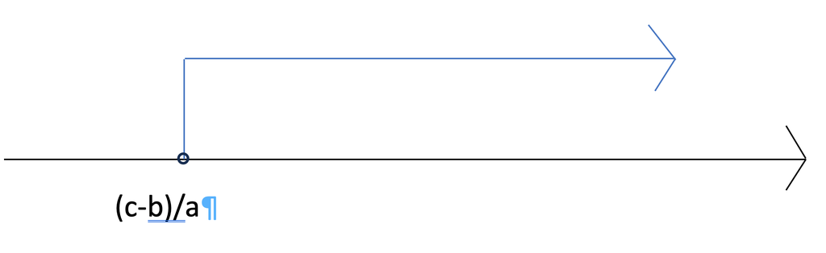

Desigualdad $ax+b>c$

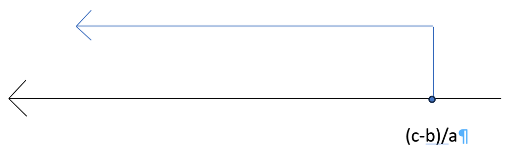

Desigualdad $ax+b\leq c$

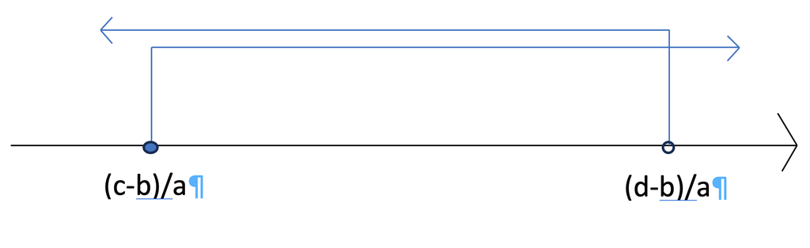

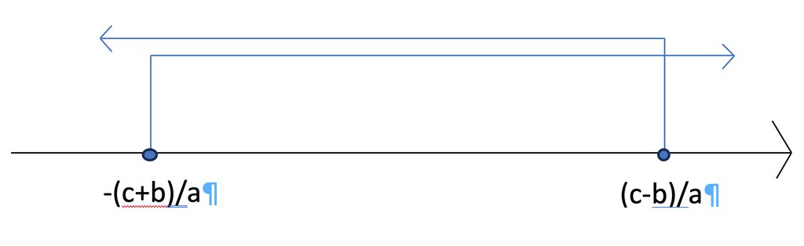

Desigualdad $|ax+b|\leq c$, con $a\neq0$

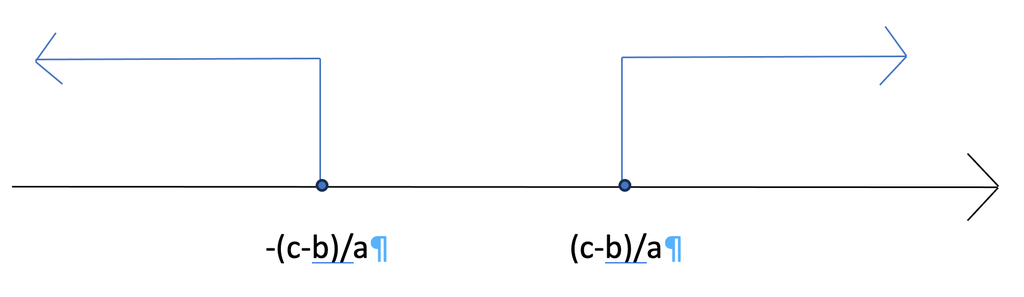

## 2.1 Solución de desigualdades de primer grado

### 2.1.1 Solución de desigualdades del tipo: $ax+b>c$

**Resuelve las siguientes desigualdades, proporcionando el conjunto solución, el intervalo solución así como la representación gráfica de la misma**

1. $2x+3>7$
2. $-5x+2>9$
3. $4x-1>3$
4. $-3x+5>8$
5. $2x+1>3x-2$
6. $3x-2>2x+4$
7. $4x+1>2x+5$
8. $-2x-3>4x-7$
9. $5x-2>3x+4$
10. $2x+4>6x-8$
11. $-4x+3>5x-2$
12. $3x-1>4x-3$
13. $2x-5>x-3$
14. $3x+2>2x-5$
15. $-2x+1>5x-8$

### 2.1.2 Solución de desigualdades del tipo: $ax+b>c$, con coeficientes fraccionarios

**Resuelve las siguientes desigualdades, proporcionando el conjunto solución, el intervalo solución así como la representación gráfica de la misma**

1. $\frac{1}{2}x+\frac{3}{4}>1$
2. $-\frac{2}{3}x+\frac{4}{5}>3$
3. $\frac{3}{4}x-\frac{1}{2}>\frac{5}{6}$
4. $-\frac{2}{5}x+\frac{1}{3}>-\frac{1}{15}$
5. $\frac{2}{3}x+\frac{1}{4}>\frac{5}{6}x-\frac{1}{2}$
6. $\frac{1}{2}x-\frac{1}{3}>-\frac{2}{5}x+\frac{7}{15}$
7. $-\frac{3}{4}x+\frac{1}{2}>\frac{2}{3}x-\frac{1}{4}$
8. $\frac{1}{3}x-\frac{2}{5}>\frac{2}{7}x-\frac{1}{7}$
9. $\frac{2}{5}x+\frac{1}{6}\geq\frac{1}{3}x+\frac{5}{6}$
10. $\frac{3}{4}x+\frac{1}{5}>\frac{1}{2}x+\frac{3}{10}$
11. $-\frac{1}{2}x+\frac{1}{3}>-\frac{3}{4}x-\frac{1}{6}$
12. $\frac{1}{4}x-\frac{1}{2}>\frac{2}{3}x-\frac{4}{6}$
13. $\frac{2}{3}x-\frac{1}{4}>\frac{3}{4}x-\frac{2}{3}$
14. $-\frac{1}{2}x+\frac{3}{4}>\frac{3}{5}x+\frac{1}{10}$
15. $\frac{2}{5}x-\frac{1}{4}>-\frac{1}{2}x+\frac{3}{8}$

### 2.1.3 Solución de desigualdades del tipo: $ax+b<c$

**Resuelve las siguientes desigualdades, proporcionando el conjunto solución, el intervalo solución así como la representación gráfica de la misma**

1. $2x+3<7$
2. $-5x+2<-9$
3. $4x-1<3$
4. $-3x+5<8$
5. $2x+1<3x-2$
6. $3x-2<2x+4$
7. $4x+1<2x+5$
8. $-2x-3<4x-7$
9. $5x-2<3x+4$
10. $2x+4<6x-8$
11. $-4x+3<5x-2$
12. $3x-1<4x-3$
13. $2x-5<x-3$
14. $3x+2<2x-5$
15. $-2x+1<5x-8$

### 2.1.4 Solución de desigualdades del tipo: $ax+b<c$ con coeficientes fraccionarios

**Resuelve las siguientes desigualdades, proporcionando el conjunto solución, el intervalo solución así como la representación gráfica de la misma**

1. $\frac{1}{2}x+\frac{3}{4}<\frac{5}{8}$
2. $-\frac{2}{3}x+\frac{4}{5}<\frac{1}{2}$
3. $\frac{3}{4}x-\frac{1}{2}<\frac{5}{6}$
4. $-\frac{2}{5}x+\frac{1}{3}<-\frac{1}{15}$
5. $\frac{2}{3}x+\frac{1}{4}<\frac{5}{6}x-\frac{1}{2}$
6. $\frac{1}{2}x-\frac{1}{3}<\frac{2}{5}x-\frac{7}{15}$
7. $-\frac{3}{4}x+\frac{1}{2}<\frac{2}{3}x-\frac{1}{4}$
8. $\frac{1}{3}x-\frac{2}{5}<\frac{2}{7}x-\frac{1}{7}$
9. $\frac{2}{5}x+\frac{1}{6}<\frac{1}{3}x+\frac{5}{6}$
10. $\frac{3}{4}x+\frac{1}{5}<\frac{1}{2}x+\frac{3}{10}$
11. $-\frac{1}{2}x+\frac{1}{3}<-\frac{3}{4}x-\frac{1}{6}$
12. $\frac{1}{4}x-\frac{1}{2}<\frac{2}{3}x-\frac{4}{6}$
13. $\frac{2}{3}x-\frac{1}{4}<\frac{3}{4}x-\frac{2}{3}$
14. $-\frac{1}{2}x+\frac{3}{4}<\frac{3}{5}x+\frac{1}{10}$
15. $\frac{2}{5}x-\frac{1}{4}<-\frac{1}{2}x+\frac{3}{8}$

### 2.1.5 Solución de desigualdades del tipo: $ax+b \geq c$

**Resuelve las siguientes desigualdades, proporcionando el conjunto solución, el intervalo solución así como la representación gráfica de la misma**

1. $2x + 3 \geq 5$
2. $-4x + 2 \geq -10$
3. $5x - 4 \geq 6$
4. $-3x + 7 \geq 4$
5. $2x - 3 \geq x + 2$
6. $3x + 2 \geq 2x - 1$
7. $4x - 1 \geq x + 5$
8. $-2x - 3 \geq -6x - 1$
9. $5x - 2 \geq 2x + 8$
10. $2x + 4 \geq 4x - 2$
11. $-4x + 3 \geq 3x - 2$
12. $3x - 1 \geq 2x + 1$
13. $2x - 5 \geq x - 1$
14. $3x + 2 \geq 2x - 4$
15. $-2x + 1 \geq -5x + 4$

### 2.1.6 Solución de desigualdades del tipo: $ax+b \geq c$, con coeficientes fraccionarios

**Resuelve las siguientes desigualdades, proporcionando el conjunto solución, el intervalo solución así como la representación gráfica de la misma**

1. $\frac{1}{2}x + \frac{3}{4} \geq \frac{5}{8}$
2. $-\frac{2}{3}x + \frac{4}{5} \geq \frac{1}{2}$
3. $\frac{3}{4}x - \frac{1}{2} \geq \frac{5}{6}$
4. $-\frac{2}{5}x + \frac{1}{3} \geq -\frac{1}{15}$
5. $\frac{2}{3}x + \frac{1}{4} \geq \frac{5}{6}x - \frac{1}{2}$
6. $\frac{1}{2}x - \frac{1}{3} \geq \frac{2}{5}x - \frac{7}{15}$
7. $-\frac{3}{4}x + \frac{1}{2} \geq \frac{2}{3}x - \frac{1}{4}$
8. $\frac{1}{3}x - \frac{2}{5} \geq \frac{2}{7}x - \frac{1}{7}$
9. $\frac{2}{5}x + \frac{1}{6} \geq \frac{1}{3}x + \frac{5}{6}$
10. $\frac{3}{4}x + \frac{1}{5} \geq \frac{1}{2}x + \frac{3}{10}$
11. $-\frac{1}{2}x + \frac{1}{3} \geq -\frac{3}{4}x - \frac{1}{6}$
12. $\frac{1}{4}x - \frac{1}{2} \geq \frac{2}{3}x - \frac{4}{6}$
13. $\frac{2}{3}x - \frac{1}{4} \geq \frac{3}{4}x - \frac{2}{3}$
14. $-\frac{1}{2}x + \frac{3}{4} \geq \frac{3}{5}x + \frac{1}{10}$
15. $\frac{2}{5}x - \frac{1}{4} \geq -\frac{1}{2}x + \frac{3}{8}$

### 2.1.7 Solución de desigualdades del tipo: $ax+b \leq c$

**Resuelve las siguientes desigualdades, proporcionando el conjunto solución, el intervalo solución así como la representación gráfica de la misma**

1. $2x + 3 \leq 7$
2. $-3x + 4 \leq 5$
3. $4x - 2 \leq 6$
4. $-5x + 3 \leq 2$
5. $2x + 1 \leq 5x - 2$
6. $3x - 1 \leq 5x + 2$
7. $-4x + 2 \leq 3x + 1$
8. $3x - 5 \leq 7x - 2$
9. $5x + 1 \leq 3x + 4$
10. $4x + 1 \leq 6x - 3$
11. $-2x + 3 \leq -4x - 1$
12. $x - 2 \leq 2x + 1$
13. $3x - 4 \leq 4x - 2$
14. $-2x + 4 \leq 5x + 1$
15. $2x - 1 \leq -3x + 4$

### 2.1.8 Solución de desigualdades del tipo: $ax+b \leq c$ con coeficientes fraccionarios.

**Resuelve las siguientes desigualdades, proporcionando el conjunto solución, el intervalo solución así como la representación gráfica de la misma**

1. $\frac{1}{2}x + \frac{3}{4} \leq \frac{5}{8}$
2. $-\frac{2}{3}x + \frac{4}{5} \leq \frac{1}{2}$
3. $\frac{3}{4}x - \frac{1}{2} \leq \frac{5}{6}$
4. $-\frac{2}{5}x + \frac{1}{3} \leq -\frac{1}{15}$
5. $\frac{2}{3}x + \frac{1}{4} \leq \frac{5}{6}x - \frac{1}{2}$
6. $\frac{1}{2}x - \frac{1}{3} \leq \frac{2}{5}x - \frac{7}{15}$
7. $-\frac{3}{4}x + \frac{1}{2} \leq \frac{2}{3}x - \frac{1}{4}$
8. $\frac{1}{3}x - \frac{2}{5} \leq \frac{2}{7}x - \frac{1}{7}$
9. $\frac{2}{5}x + \frac{1}{6} \leq \frac{1}{3}x + \frac{5}{6}$
10. $\frac{3}{4}x + \frac{1}{5} \leq \frac{1}{2}x + \frac{3}{10}$
11. $-\frac{1}{2}x + \frac{1}{3} \leq -\frac{3}{4}x - \frac{1}{6}$
12. $\frac{1}{4}x - \frac{1}{2} \leq \frac{2}{3}x - \frac{4}{6}$
13. $\frac{2}{3}x - \frac{1}{4} \leq \frac{3}{4}x - \frac{2}{3}$
14. $-\frac{1}{2}x + \frac{3}{4} \leq \frac{3}{5}x + \frac{1}{10}$
15. $\frac{2}{5}x - \frac{1}{4} \leq -\frac{1}{2}x + \frac{3}{8}$

## 2.2 Solución de desigualdades con doble desigualdad.

### 2.2.1 Solución de desigualdades del tipo: $c< ax+b <d$

**Resuelve las siguientes desigualdades, proporcionando el conjunto solución, el intervalo solución así como la representación gráfica de la misma**

1. $2<x+3<5$
2. $-1<2x-1<1$
3. $-\frac{1}{2}<\frac{3}{4}x+\frac{1}{2}<\frac{1}{2}$
4. $-3< 2x+7<-1$
5. $1<\frac{1}{2}x-\frac{1}{4}<2$
6. $-5<-\frac{1}{3}x+\frac{5}{6}<1$
7. $-5<5x-1<8$
8. $-2< \frac{2}{3}x+1<12$
9. $2<-\frac{1}{2}x+\frac{3}{4}<3$
10. $-3< \frac{1}{2}x-\frac{1}{3}<18$
11. $-4< -3x+5<3$
12. $1<\frac{1}{2}x+\frac{1}{3}<2$
13. $-2< 4x-1<2$
14. $-\frac{3}{4}<\frac{1}{2}x-\frac{1}{4}<\frac{3}{4}$
15. $-1<s\frac{3}{2}x+1<2$

### 2.2.2 Solución de desigualdades del tipo: $c< ax+b \leq d$

**Resuelve las siguientes desigualdades, proporcionando el conjunto solución, el intervalo solución así como la representación gráfica de la misma**

1. $-2<3x+1\leq 5$
2. $-\frac{4}{5}< \frac{1}{2}x-\frac{3}{4}\leq2$
3. $-1<2x-1\leq 1$
4. $-3< \frac{1}{2}x+\frac{1}{3}\leq \frac{8}{5}$
5. $-\frac{3}{4}<\frac{1}{2}x+\frac{1}{4}\leq \frac{3}{4}$
6. $-2<\frac{3}{2}x-1\leq 1$
7. $-1<\frac{2}{3}x+1\leq \frac{8}{3}$
8. $1<\frac{1}{2}x+\frac{1}{3}\leq 2$
9. $-3< -2x+5\leq 3$
10. $-\frac{1}{2}<\frac{3}{4}x+\frac{1}{2}\leq \frac{1}{2}$
11. $-5<5x-1\leq 9$
12. $1<\frac{1}{2}x-\frac{1}{4}\leq 2$
13. $-3< 2x+7\leq -1$
14. $-1< -\frac{1}{2}x+\frac{1}{4}\leq 2$
15. $2<-\frac{1}{2}x+\frac{3}{4}\leq 3$

### 2.2.3 Solución de desigualdades del tipo: $c\leq ax+b <d$

**Resuelve las siguientes desigualdades, proporcionando el conjunto solución, el intervalo solución así como la representación gráfica de la misma**

1. $-2\leq 3x+1<5$
2. $-\frac{4}{5}\leq \frac{1}{2}x-\frac{3}{4}<2$
3. $-1\leq 2x-1<1$
4. $-3\leq \frac{1}{2}x+\frac{1}{3}<\frac{7}{9}$
5. $-\frac{3}{4}\leq \frac{1}{2}x+\frac{1}{4}<\frac{3}{4}$
6. $-2\leq \frac{3}{2}x-1<1$
7. $-1\leq \frac{2}{3}x+1<\frac{9}{4}$
8. $1\leq \frac{1}{2}x+\frac{1}{3}<2$
9. $-\frac{4}{3}\leq -2x+5<3$
10. $-\frac{1}{2}\leq \frac{3}{4}x+\frac{1}{2}<\frac{1}{2}$
11. $-5\leq 5x-1<\frac{15}{6}$
12. $1\leq \frac{1}{2}x-\frac{1}{4}<2$
13. $-3\leq 2x+7<-1$
14. $-1\leq -\frac{1}{2}x+\frac{1}{4}<2$
15. $2\leq -\frac{1}{2}x+\frac{3}{4}<3$

### 2.2.4 Solución de desigualdades del tipo: $c\leq ax+b \leq d$

**Resuelve las siguientes desigualdades, proporcionando el conjunto solución, el intervalo solución así como la representación gráfica de la misma**

1. $-1\leq x\leq 2$
2. $-\frac{3}{4}\leq \frac{1}{2}x+\frac{1}{4}\leq \frac{5}{8}$
3. $2\leq 3x-1\leq 7$
4. $-\frac{1}{3}\leq \frac{1}{6}x+\frac{1}{2}\leq \frac{1}{2}$
5. $-1\leq -x+3\leq 2$
6. $-2\leq \frac{1}{2}x+1\leq 3$
7. $2\leq \frac{3}{2}x+1\leq 5$
8. $-\frac{3}{4}\leq -\frac{1}{2}x+\frac{1}{4}\leq \frac{1}{4}$
9. $-4\leq 2x+1\leq 7$
10. $-\frac{1}{2}\leq -\frac{3}{4}x+\frac{1}{2}\leq 1$
11. $-\frac{5}{2}\leq \frac{1}{4}x+1\leq 1$
12. $1\leq -\frac{1}{2}x+\frac{3}{4}\leq 3$
13. $-\frac{5}{6}\leq \frac{1}{3}x+\frac{1}{2}\leq \frac{1}{2}$
14. $-1\leq \frac{1}{2}x-\frac{1}{4}\leq 3$
15. $-2\leq \frac{1}{4}x+\frac{1}{2}\leq 3$

## 2.3 Solución de desigualdades con valor absoluto

### 2.3.1 Solución de desigualdades del tipo: $|ax+b| <d$

**Resuelve las siguientes desigualdades, proporcionando el conjunto solución, el intervalo solución así como la representación gráfica de la misma**

1. $|2x+1|<5$
2. $|\frac{1}{2}x-\frac{1}{4}|<2$
3. $|3x-1|<7$
4. $|\frac{1}{3}x+\frac{1}{2}|<1$
5. $|x-2|<4$
6. $|\frac{1}{2}x+1|<3$
7. $|\frac{3}{2}x+1|<5$
8. $|\frac{1}{2}x-\frac{1}{4}|<\frac{3}{4}$
9. $|2x+1|<6$
10. $|\frac{3}{4}x-\frac{1}{2}|<1$
11. $|\frac{1}{4}x+1|<\frac{7}{2}$
12. $|-\frac{1}{2}x+\frac{3}{4}|<2$
13. $|\frac{1}{3}x+\frac{1}{2}|<\frac{5}{6}$
14. $|\frac{1}{2}x-\frac{1}{4}|<3$
15. $|\frac{1}{4}x+\frac{1}{2}|<\frac{7}{4}$

### 2.3.2 Solución de desigualdades del tipo: $|ax+b| \leq d$

**Resuelve las siguientes desigualdades, proporcionando el conjunto solución, el intervalo solución así como la representación gráfica de la misma**

1. $|3x-1|\leq 6$
2. $|\frac{1}{2}x-\frac{1}{4}|\leq 1$
3. $|2x+1|\leq 5$
4. $|\frac{1}{3}x+\frac{1}{2}|\leq \frac{4}{3}$
5. $|x-2|\leq 3$
6. $|\frac{1}{2}x+1|\leq 4$
7. $|\frac{3}{2}x+1|\leq 5$
8. $|\frac{1}{2}x-\frac{1}{4}|\leq \frac{5}{4}$
9. $|2x+1|\leq 7$
10. $|\frac{3}{4}x-\frac{1}{2}|\leq 2$
11. $|\frac{1}{4}x+1|\leq 3$
12. $|-\frac{1}{2}x+\frac{3}{4}|\leq 2$
13. $|\frac{1}{3}x+\frac{1}{2}|\leq 1$

14, $|\frac{1}{2}x-\frac{1}{4}|\leq 2$

15. $|\frac{1}{4}x+\frac{1}{2}|\leq \frac{5}{4}$

### 2.3.3 Solución de desigualdades del tipo: $|ax+b| >d$

**Resuelve las siguientes desigualdades, proporcionando el conjunto solución, el intervalo solución así como la representación gráfica de la misma**

1. $|3x-1|>4$
2. $|\frac{1}{2}x-\frac{1}{4}|>\frac{1}{2}$
3. $|2x+1|>3$
4. $|\frac{1}{3}x+\frac{1}{2}|>\frac{5}{6}$
5. $|x-2|>1$
6. $|\frac{1}{2}x+1|>\frac{3}{4}$
7. $|\frac{3}{2}x+1|>\frac{7}{2}$
8. $|\frac{1}{2}x-\frac{1}{4}|>\frac{3}{4}$
9. $|2x+1|>\frac{9}{2}$
10. $|\frac{3}{4}x-\frac{1}{2}|>\frac{5}{4}$
11. $|\frac{1}{4}x+1|>1$
12. $|-\frac{1}{2}x+\frac{3}{4}|>\frac{1}{2}$
13. $|\frac{1}{3}x+\frac{1}{2}|>\frac{2}{3}$
14. $|\frac{1}{2}x-\frac{1}{4}|>\frac{5}{4}$
15. $|\frac{1}{4}x+\frac{1}{2}|>1$

### 2.3.4 Solución de desigualdades del tipo: $|ax+b| \geq d$

**Resuelve las siguientes desigualdades, proporcionando el conjunto solución, el intervalo solución así como la representación gráfica de la misma**

1. $|3x-1|\geq 4$
2. $|\frac{1}{2}x-\frac{1}{4}|\geq\frac{1}{2}$
3. $|2x+1|\geq 3$
4. $|\frac{1}{3}x+\frac{1}{2}|\geq\frac{5}{6}$
5. $|x-2|\geq 1$
6. $|\frac{1}{2}x+1|\geq\frac{3}{4}$
7. $|\frac{3}{2}x+1|\geq\frac{7}{2}$
8. $|\frac{1}{2}x-\frac{1}{4}|\geq\frac{3}{4}$
9. $|2x+1|\geq\frac{9}{2}$
10. $|\frac{3}{4}x-\frac{1}{2}|\geq\frac{5}{4}$
11. $|\frac{1}{4}x+1|\geq 1$
12. $|-\frac{1}{2}x+\frac{3}{4}|\geq\frac{1}{2}$
13. $|\frac{1}{3}x+\frac{1}{2}|\geq\frac{2}{3}$
14. $|\frac{1}{2}x-\frac{1}{4}|\geq\frac{5}{4}$
15. $|\frac{1}{4}x+\frac{1}{2}|\geq 1$

### 2.3.5 Ejercicios adicionales

1. Resuelve los ejercicios siguientes, encuentra el intervalo solución y proporciona su gráfica
   1. $|-\frac{1}{3}x+\frac{2}{5}| \leq \frac{4}{5}$
   2. $|-\frac{2}{7}x-\frac{3}{4}| \leq \frac{2}{3}$
   3. $|\frac{5}{8}x-\frac{1}{6}| \leq \frac{7}{8}$
   4. $|\frac{3}{10}x+\frac{2}{9}| \leq \frac{1}{2}$
   5. $|-\frac{4}{11}x+\frac{5}{7}| \leq \frac{3}{4}$
   6. $|-\frac{2}{5}x-\frac{1}{3}| \leq \frac{2}{5}$
   7. $|\frac{1}{6}x+\frac{7}{9}| \leq \frac{1}{3}$
   8. $|\frac{7}{9}x-\frac{4}{11}| \leq \frac{5}{6}$
   9. $|-\frac{5}{8}x+\frac{3}{10}| \leq \frac{2}{7}$
   10. $|-\frac{1}{4}x-\frac{1}{8}| \leq \frac{3}{4}$
   11. $|\frac{3}{7}x+\frac{5}{6}| \leq \frac{1}{5}$
   12. $|-\frac{4}{9}x+\frac{2}{11}| \leq \frac{4}{9}$
   13. $|-\frac{2}{5}x-\frac{7}{8}| \leq \frac{2}{3}$
   14. $|\frac{5}{11}x+\frac{1}{7}| \leq \frac{5}{11}$
   15. $|\frac{3}{8}x-\frac{2}{9}| \leq \frac{3}{4}$
2. Realiza lo mismo para los siguientes ejercicios
   1. $|-\frac{2}{5}x+\frac{3}{4}| \leq \frac{1}{2}$
   2. $|\frac{3}{7}x+\frac{1}{8}| \leq \frac{2}{7}$
   3. $|-{\frac{5}{6}x-\frac{4}{9}}| \leq \frac{5}{6}$
   4. $|-\frac{4}{9}x+\frac{2}{11}| \leq \frac{3}{4}$
   5. $|-\frac{1}{3}x-\frac{2}{7}| \leq \frac{3}{5}$
   6. $|\frac{3}{8}x-\frac{1}{6}| \leq \frac{2}{5}$
   7. $|-{\frac{2}{7}x+\frac{5}{8}}| \leq \frac{3}{7}$
   8. $|\frac{5}{11}x+\frac{1}{3}| \leq \frac{4}{11}$
   9. $|-\frac{4}{5}x-\frac{3}{10}| \leq \frac{1}{4}$
   10. $|-\frac{1}{4}x+\frac{7}{9}| \leq \frac{5}{8}$
   11. $|-{\frac{2}{9}x-\frac{1}{5}}| \leq \frac{2}{9}$
   12. $|-\frac{3}{10}x+\frac{2}{7}| \leq \frac{4}{9}$
   13. $|\frac{5}{8}x-\frac{1}{3}| \leq \frac{3}{8}$
   14. $|\frac{4}{11}x+\frac{5}{6}| \leq \frac{2}{5}$
   15. $|-\frac{2}{5}x-\frac{3}{8}| \leq \frac{5}{6}$
   16. $|\frac{1}{6}x-\frac{2}{9}| \leq \frac{1}{4}$
   17. $|-{\frac{5}{9}x+\frac{4}{11}}| \leq \frac{2}{3}$
   18. $|-\frac{3}{8}x+\frac{1}{5}| \leq \frac{3}{8}$
   19. $|-\frac{4}{7}x-\frac{3}{10}| \leq \frac{1}{7}$
   20. $|-\frac{2}{11}x+\frac{5}{8}| \leq \frac{3}{10}$
3. Finalmente realiza lo mismo para la siguiente lista:
   1. $|{-\frac{4}{9}x+\frac{5}{8}}| \geq \frac{1}{3}$
   2. $|{-\frac{1}{6}x-\frac{2}{7}}| > \frac{2}{5}$
   3. $|{\frac{7}{11}x+\frac{1}{8}}| \leq \frac{3}{7}$
   4. $|{-\frac{3}{8}x+\frac{4}{9}}| < \frac{5}{8}$
   5. $|{-\frac{5}{6}x+\frac{3}{10}}| \geq \frac{2}{3}$
   6. $|{-\frac{2}{7}x-\frac{1}{4}}| \leq \frac{5}{6}$
   7. $|{-\frac{1}{3}x+\frac{5}{9}}| > \frac{2}{7}$
   8. $|{\frac{4}{11}x-\frac{3}{8}}| \leq \frac{1}{5}$
   9. $|{-\frac{2}{9}x+\frac{1}{7}}| \geq \frac{3}{4}$
   10. $|{-\frac{5}{8}x+\frac{2}{11}}| < \frac{4}{9}$
   11. $|{\frac{1}{4}x+\frac{7}{9}}| \leq \frac{2}{7}$
   12. $|{-\frac{3}{10}x-\frac{5}{6}}| > \frac{1}{3}$
   13. $|{-\frac{4}{5}x+\frac{1}{6}}| \geq \frac{2}{5}$
   14. $|{-\frac{3}{7}x+\frac{4}{9}}| < \frac{3}{7}$
   15. $|{\frac{5}{11}x-\frac{2}{8}}| \leq \frac{4}{11}$
   16. $|{-\frac{2}{11}x-\frac{3}{8}}| > \frac{1}{6}$
   17. $|{-\frac{5}{9}x+\frac{2}{7}}| \geq \frac{3}{4}$
   18. $|{-\frac{3}{8}x-\frac{1}{6}}| < \frac{5}{11}$
   19. $|{\frac{4}{7}x+\frac{1}{5}}| \leq \frac{3}{10}$
   20. $|{-\frac{1}{5}x+\frac{6}{11}}| > \frac{2}{9}$
4. Un poco más de ejercicios finales
   1. $|\frac{3x+2}{5}| \geq \frac{1}{4}$
   2. $|-\frac{6x-1}{2}| \leq \frac{3}{5}$
   3. $|\frac{-2x+9}{7}| > \frac{4}{9}$
   4. $|-\frac{-5x-3}{4}| \geq \frac{2}{7}$
   5. $|\frac{4x+7}{3}| < \frac{5}{6}$
   6. $|-\frac{9x-2}{8}| \leq \frac{7}{10}$
   7. $|\frac{-8x+3}{6}| > \frac{1}{5}$
   8. $|\frac{-7x-5}{9}| \geq \frac{2}{11}$
   9. $|-\frac{12x+4}{11}| < \frac{3}{8}$
   10. $|\frac{11x-6}{10}| \leq \frac{5}{9}$
   11. $|\frac{-15x+2}{13}| > \frac{4}{11}$
   12. $|-\frac{-14x-7}{8}| \geq \frac{3}{7}$
   13. $|\frac{17x+1}{9}| < \frac{2}{5}$
   14. $|-\frac{18x-9}{5}| \leq \frac{7}{12}$
   15. $|\frac{-21x+5}{4}| > \frac{1}{3}$
   16. $|-\frac{-23x-2}{7}| \geq \frac{4}{9}$
   17. $|\frac{25x+8}{6}| < \frac{2}{7}$
   18. $|-\frac{27x-3}{10}| \leq \frac{5}{11}$
   19. $|\frac{-29x+6}{11}| > \frac{3}{8}$
   20. $|-\frac{-31x-4}{9}| \geq \frac{1}{5}$
5. Ejercicios finales
   1. $|\frac{2x+3}{4}-\frac{5}{6}| \geq \frac{7}{8}$
   2. $|-\frac{3x-1}{2}+\frac{4}{5}| \leq \frac{6}{7}$
   3. $|\frac{-7x+11}{9}-\frac{13}{14}| > \frac{15}{16}$
   4. $|\frac{-4x-9}{5}+\frac{2}{3}| \geq \frac{8}{9}$
   5. $|-\frac{5x+7}{8}-\frac{10}{11}| < \frac{12}{13}$
   6. $|\frac{6x-5}{4}+\frac{8}{7}| \leq \frac{9}{10}$
   7. $|\frac{-9x+2}{11}-\frac{13}{15}| > \frac{17}{18}$
   8. $|-\frac{-2x-1}{10}+\frac{14}{13}| \geq \frac{16}{17}$
   9. $|-\frac{8x+3}{6}-\frac{7}{9}| < \frac{5}{8}$
   10. $|\frac{11x-4}{7}+\frac{9}{12}| \leq \frac{13}{14}$
   11. $|-\frac{-14x+5}{15}-\frac{17}{18}| > \frac{19}{20}$
   12. $|\frac{-10x-7}{13}+\frac{12}{11}| \geq \frac{16}{15}$
   13. $|\frac{13x+9}{8}-\frac{14}{15}| < \frac{7}{9}$
   14. $|-\frac{15x-2}{11}+\frac{10}{9}| \leq \frac{4}{5}$
   15. $|\frac{-17x+6}{5}-\frac{8}{7}| > \frac{3}{4}$
   16. $|-\frac{-19x-8}{4}+\frac{12}{11}| \geq \frac{5}{6}$
   17. $|\frac{21x+4}{3}-\frac{10}{9}| < \frac{13}{14}$
   18. $|-\frac{23x-5}{2}+\frac{14}{15}| \leq \frac{16}{17}$
   19. $|\frac{-16x+7}{9}-\frac{11}{10}| > \frac{8}{9}$
   20. $|-\frac{-18x-3}{7}+\frac{9}{6}| \geq \frac{14}{13}$

## 2.4 Solución de desigualdades de segundo grado

### 2.4.1 Solución de desigualdades del tipo $ax^2+bx+c>0$

**Resuelve las siguientes desigualdades, proporcionando el conjunto solución, el intervalo solución así como la representación gráfica de la misma**

1. $x^2-3x+2>0$
2. $2x^2-5x+2>0$
3. $3x^2+2x-1>0$
4. $x^2-\frac{3}{2}x+\frac{1}{2}>0$
5. $\frac{1}{2}x^2-2x+2>0$
6. $x^2+2x+1>0$
7. $\frac{1}{4}x^2-\frac{1}{2}x+1>0$
8. $\frac{1}{3}x^2-\frac{4}{3}x+1>0$
9. $4x^2-12x+9>0$
10. $\frac{3}{2}x^2-5x+2>0$
11. $2x^2-7x+6>0$
12. $\frac{1}{2}x^2+\frac{1}{2}x-1>0$
13. $\frac{1}{5}x^2-\frac{2}{5}x+\frac{1}{2}>0$
14. $x^2+\frac{1}{2}x-\frac{1}{2}>0$
15. $3x^2-10x+6>0$

### 2.4.2 Solución de desigualdades del tipo $ax^2+bx+c\geq 0$

**Resuelve las siguientes desigualdades, proporcionando el conjunto solución, el intervalo solución así como la representación gráfica de la misma**

1. $x^2-4x+3\geq 0$
2. $2x^2-6x+4\geq 0$
3. $3x^2+2x+1\geq 0$
4. $x^2-\frac{3}{2}x+\frac{1}{2}\geq 0$
5. $\frac{1}{2}x^2-2x+2\geq 0$
6. $x^2+2x+1\geq 0$
7. $\frac{1}{4}x^2-\frac{1}{2}x+1\geq 0$
8. $\frac{1}{3}x^2-\frac{4}{3}x+1\geq 0$
9. $4x^2-12x+9\geq 0$
10. $\frac{3}{2}x^2-5x+2\geq 0$
11. $2x^2-7x+6\geq 0$
12. $\frac{1}{2}x^2+\frac{1}{2}x-1\geq 0$
13. $\frac{1}{5}x^2-\frac{2}{5}x+\frac{1}{2}\geq 0$
14. $x^2+\frac{1}{2}x-\frac{1}{2}\geq 0$
15. $3x^2-10x+6\geq 0$

### 2.4.3 Solución de desigualdades del tipo $ax^2+bx+c<0$

**Resuelve las siguientes desigualdades, proporcionando el conjunto solución, el intervalo solución así como la representación gráfica de la misma**

1. $x^2-4x+3<0$
2. $2x^2-5x-3<0$
3. $\frac{1}{2}x^2-\frac{5}{2}x+1<0$
4. $3x^2-7x+2<0$
5. $-x^2+6x-9<0$
6. $\frac{1}{3}x^2+\frac{5}{3}x+1<0$
7. $2x^2+5x+2<0$
8. $-4x^2+16x-12<0$
9. $\frac{1}{4}x^2-\frac{5}{2}x+4<0$
10. $x^2-9<0$
11. $4x^2-12x+8<0$
12. $-2x^2+3x+1<0$
13. $3x^2-2x-1<0$
14. $-x^2+x+12<0$
15. $\frac{3}{2}x^2-\frac{5}{2}x-1<0$

### 2.4.4 Solución de desigualdades del tipo $ax^2+bx+c\leq 0$

**Resuelve las siguientes desigualdades, proporcionando el conjunto solución, el intervalo solución así como la representación gráfica de la misma**

1. $x^2-2x+1\leq0$
2. $-3x^2+4x+1\leq0$
3. $\frac{1}{2}x^2-2x+2\leq0$
4. $2x^2-7x+3\leq0$
5. $-x^2+4x-4\leq0$
6. $\frac{1}{4}x^2+\frac{5}{2}x+5\leq0$
7. $3x^2+4x+1\leq0$
8. $-4x^2+4x+4\leq0$
9. $\frac{1}{3}x^2+\frac{5}{3}x+2\leq0$
10. $x^2-16\leq0$
11. $2x^2-8x+8\leq0$
12. $-x^2+3x+6\leq0$
13. $3x^2-2x-2\leq0$
14. $-2x^2+3x+3\leq0$
15. $\frac{1}{2}x^2-\frac{5}{2}x+2\leq0$

### 2.4.5 Ejercicios adicionales

**a. Resuelve las siguientes desigualdades de segundo orden proporcionando su conjunto solución y su gráfica**

1. $3x^2 - 2x + 1 \geq 0$
2. $-2x^2 + 5x - 3 \leq 0$
3. $x^2 + 4x + 2 \geq 0$
4. $4x^2 - 6x + 3 \leq 0$
5. $-x^2 + 3x - 2 \geq 0$
6. $2x^2 - 7x + 4 \leq 0$
7. $-3x^2 + 2x + 5 \geq 0$
8. $x^2 - 4x + 5 \leq 0$
9. $-2x^2 + 3x - 1 \geq 0$
10. $5x^2 - 2x + 2 \leq 0$
11. $-x^2 + 6x - 5 \geq 0$
12. $3x^2 + 5x + 6 \leq 0$
13. $-4x^2 - 3x + 7 \geq 0$
14. $2x^2 + x - 3 \leq 0$
15. $-x^2 - 2x + 4 \geq 0$

**b. Resuelve las siguientes desigualdades de segundo orden proporcionando su conjunto solución y su gráfica**

1. $-\frac{2}{7}x^2 + \frac{6}{5}x - \frac{5}{6} \leq 0$
2. $\frac{7}{8}x^2 - \frac{3}{2}x + \frac{2}{5} \geq 0$
3. $-\frac{3}{4}x^2 + \frac{5}{6}x - \frac{1}{3} \leq 0$
4. $\frac{4}{5}x^2 - \frac{1}{7}x + \frac{3}{4} \geq 0$
5. $-\frac{1}{6}x^2 + \frac{2}{9}x - \frac{4}{11} \leq 0$
6. $\frac{5}{9}x^2 - \frac{3}{8}x + \frac{7}{10} \geq 0$
7. $-\frac{2}{11}x^2 + \frac{4}{5}x - \frac{1}{6} \leq 0$
8. $\frac{3}{4}x^2 - \frac{1}{3}x + \frac{5}{7} \geq 0$
9. $-\frac{4}{5}x^2 + \frac{2}{7}x - \frac{3}{8} \leq 0$
10. $\frac{1}{2}x^2 - \frac{5}{9}x + \frac{4}{7} \geq 0$
11. $-\frac{5}{6}x^2 + \frac{3}{4}x - \frac{2}{5} \leq 0$
12. $\frac{2}{7}x^2 - \frac{1}{3}x + \frac{5}{8} \geq 0$
13. $-\frac{3}{8}x^2 + \frac{2}{5}x - \frac{4}{7} \leq 0$
14. $\frac{4}{9}x^2 - \frac{3}{7}x + \frac{1}{5} \geq 0$
15. $-\frac{1}{5}x^2 + \frac{4}{11}x - \frac{2}{9} \leq 0$

**c. Resuelve las siguientes desigualdades de segundo orden proporcionando su conjunto solución y su gráfica**

1. $-\frac{5}{11}x^2 + \frac{3}{8}x - \frac{2}{6} \leq 0$
2. $\frac{2}{5}x^2 - \frac{1}{6}x + \frac{4}{11} \geq 0$
3. $-\frac{3}{4}x^2 + \frac{2}{5}x - \frac{1}{7} \leq 0$
4. $\frac{4}{7}x^2 - \frac{3}{8}x + \frac{2}{9} \geq 0$
5. $-\frac{1}{9}x^2 + \frac{4}{11}x - \frac{3}{10} \leq 0$
6. $\frac{3}{2}x^2 - \frac{5}{4}x + \frac{1}{3} \geq 0$
7. $-\frac{1}{3}x^2 + \frac{4}{5}x - \frac{2}{7} \leq 0$
8. $\frac{2}{5}x^2 + \frac{3}{4}x + \frac{7}{8} \geq 0$
9. $-\frac{4}{9}x^2 + \frac{2}{7}x - \frac{3}{5} < 0$
10. $\frac{5}{6}x^2 - \frac{1}{3}x + \frac{4}{9} > 0$
11. $-\frac{2}{7}x^2 + \frac{6}{5}x - \frac{5}{6} \leq 0$
12. $\frac{7}{8}x^2 - \frac{3}{2}x + \frac{2}{5} \geq 0$
13. $-\frac{3}{4}x^2 + \frac{5}{6}x - \frac{1}{3} \leq 0$
14. $\frac{4}{5}x^2 - \frac{1}{7}x + \frac{3}{4} > 0$
15. $-\frac{1}{6}x^2 + \frac{2}{9}x - \frac{4}{11} \geq 0$

**d. Resuelve las siguientes desigualdades de segundo orden proporcionando su conjunto solución y su gráfica**

1. $-\frac{5}{6}x^2 + \frac{3}{4}x - \frac{2}{5} \geq 0$
2. $\frac{2}{7}x^2 - \frac{1}{3}x + \frac{5}{8} \leq 0$
3. $-\frac{3}{8}x^2 + \frac{2}{5}x - \frac{4}{7} > 0$
4. $\frac{4}{9}x^2 - \frac{3}{7}x + \frac{1}{5} \geq 0$
5. $-\frac{1}{5}x^2 + \frac{4}{11}x - \frac{2}{9} < 0$
6. $\frac{5}{6}x^2 - \frac{1}{3}x + \frac{4}{9} \leq 0$
7. $-\frac{2}{9}x^2 + \frac{6}{7}x - \frac{5}{8} \geq 0$
8. $\frac{3}{8}x^2 - \frac{5}{6}x + \frac{2}{5} < 0$
9. $-\frac{4}{7}x^2 + \frac{2}{3}x - \frac{1}{4} \leq 0$
10. $\frac{1}{4}x^2 - \frac{5}{9}x + \frac{3}{7} \geq 0$
11. $-\frac{5}{11}x^2 + \frac{3}{8}x - \frac{2}{6} < 0$
12. $\frac{2}{5}x^2 - \frac{1}{6}x + \frac{4}{11} \leq 0$
13. $-\frac{3}{4}x^2 + \frac{2}{5}x - \frac{1}{7} \geq 0$
14. $\frac{4}{7}x^2 - \frac{3}{8}x + \frac{2}{9} < 0$
15. $-\frac{1}{9}x^2 + \frac{4}{11}x - \frac{3}{10} \geq 0$

**e. Resuelve las siguientes desigualdades de segundo orden proporcionando su conjunto solución y su gráfica**

1. $\frac{5}{6}x^2 - \frac{1}{3}x + \frac{4}{9} \geq 0$
2. $-\frac{2}{9}x^2 + \frac{6}{7}x - \frac{5}{8} \leq 0$
3. $\frac{3}{8}x^2 - \frac{5}{6}x + \frac{2}{5} \geq 0$
4. $-\frac{4}{7}x^2 + \frac{2}{3}x - \frac{1}{4} \leq 0$
5. $\frac{1}{4}x^2 - \frac{5}{9}x + \frac{3}{7} \geq 0$
6. $\frac{5}{9}x^2 - \frac{3}{8}x + \frac{7}{10} \leq 0$
7. $-\frac{2}{11}x^2 + \frac{4}{5}x - \frac{1}{6} < 0$
8. $\frac{3}{4}x^2 - \frac{1}{3}x + \frac{5}{7} \geq 0$
9. $-\frac{4}{5}x^2 + \frac{2}{7}x - \frac{3}{8} \leq 0$
10. $\frac{1}{2}x^2 - \frac{5}{9}x + \frac{4}{7} < 0$
11. $\frac{3}{2}x^2 - \frac{5}{4}x + \frac{1}{3} \geq 0$
12. $-\frac{1}{3}x^2 + \frac{4}{5}x - \frac{2}{7} \leq 0$
13. $\frac{2}{5}x^2 + \frac{3}{4}x + \frac{7}{8} \geq 0$
14. $-\frac{4}{9}x^2 + \frac{2}{7}x - \frac{3}{5} \leq 0$
15. $\frac{5}{6}x^2 - \frac{1}{3}x + \frac{4}{9} \geq 0$

# 3. Funciones

## Dominio e Imagen de Funciones

**I. Para las siguientes funciones determina su dominio e imagen**

1. $f(x) = 2x + 3$
2. $f(x) = x^2 - 4x + 5$
3. $f(x) = \frac{1}{x - 1}$
4. $f(x) = |2x - 5|$
5. $f(x) = -0.5x + 2$
6. $f(x) = 3x^2 + 6x + 2$
7. $f(x) = \frac{2x}{x^2 + 1}$
8. $f(x) = |x + 3|$
9. $f(x) = 0.7x - 4$
10. $f(x) = -x^2 + 3x - 1$
11. $f(x) = \frac{3}{x + 2}$
12. $f(x) = |4x - 7|$
13. $f(x) = -x + 1$
14. $f(x) = 2x^2 - 8x + 7$
15. $f(x) = \frac{x - 4}{x + 4}$
16. $f(x) = 2x - 3$
17. $f(x) = x^2 + 4x + 4$
18. $f(x) = \frac{x - 1}{x + 2}$
19. $f(x) = 3x - 2$
20. $f(x) = -x^2 + 4x + 1$
21. $f(x) = \frac{2}{x - 3}$
22. $f(x) = |5x - 3|$
23. $f(x) = 0.5x + 4$
24. $f(x) = 2x^2 - 6x + 3$
25. $f(x) = \frac{x^2 - 4}{x + 2}$
26. $f(x) = |x - 1|$
27. $f(x) = -0.3x + 5$
28. $f(x) = -3x^2 + 2x - 4$
29. $f(x) = \frac{x^3 - 1}{x - 1}$
30. $f(x) = |3x + 2|$
31. $f(x) = 2x - 7$
32. $f(x) = x^2 + 2x - 3$
33. $f(x) = \frac{x^2 + 1}{x - 2}$
34. $f(x) = |6x - 5|$
35. $f(x) = \frac{x^2 - 9}{x - 3}$

**II. Para las siguientes funciones determina su dominio, imagen y función**

1. $f(x) = \sqrt{x + 3}$
2. $f(x) = \sqrt{2x + 5}$
3. $f(x) = \sqrt{3x - 1}$
4. $f(x) = \sqrt{4x^2 + 3x + 2}$
5. $f(x) = \sqrt{0.5x + 1}$
6. $f(x) = \sqrt{-2x + 7}$
7. $f(x) = \sqrt{-4x + 2}$
8. $f(x) = \sqrt{\frac{2}{3}x+1}$
9. $f(x) = \sqrt{3x^2 + 2x + 1}$
10. $f(x) = \sqrt{x^2 + 4x + 3}$
11. $f(x) = \sqrt{2x^2 + 6x + 5}$
12. $f(x) = \sqrt{x^2 - 9}$
13. $f(x) = \sqrt{3x^2 + 2x + 1}$
14. $f(x) = \sqrt{-x^2 + 5x - 6}$
15. $f(x) = \sqrt{4x^2 - 4}$
16. $f(x) = \sqrt{6x^{2} + 2x + 1}$
17. $f(x) = \sqrt{\frac{x^2 - 4}{x + 2}}$
18. $f(x) = \sqrt{2x^2 + 3x + 4}$
19. $f(x) = \frac{2x^2 + 4x + 2}{x + 1}$
20. $f(x) = \frac{3x^2 + 6x + 3}{2x + 2}$
21. $f(x) = \frac{x^2 - 4}{x - 2}$
22. $f(x) = \frac{4x^2 + 6x + 2}{3x + 9}$
23. $f(x) = \frac{2x^2 + 5x + 3}{x + 3}$
24. $f(x) = \frac{x^2 - 1}{2x - 2}$
25. $f(x) = \frac{2x^2 - x - 1}{x - 1}$
26. $f(x) = \frac{x^2-9}{3x - 9}$
27. $f(x) = \frac{2x^2 + 4x + 2}{3x + 3}$

**III. Ejercicios adicionales**

1. $f(x) =\sqrt{2x - 5}$
2. $f(x) =\sqrt{3x^2 + 4x - 1}$
3. $f(x) =\sqrt{4x^2 - 9}$
4. $f(x) =\sqrt{5x^2 - 2x + 7}$
5. $f(x) =\sqrt{-6x + 10}$
6. $f(x) =\sqrt{7x^2 + 8x - 6}$
7. $f(x) =\sqrt{8x^2 - 16x + 4}$
8. $f(x) =\sqrt{-9x^2 + 25}$
9. $f(x) =\sqrt{-10x^2 - 7x - 2}$
10. $f(x) =\sqrt{-11x^2 + 3x + 9}$
11. $f(x) =\sqrt{2x^2 - 3x + 5}$
12. $f(x) =\sqrt{3x^2 + 4x - 1}$
13. $f(x) =\sqrt{4x - 9}$
14. $f(x) =\sqrt{5x^2 - 2x + 7}$
15. $f(x) =\sqrt{-6x^2 + 10x - 4}$
16. $f(x) =\sqrt{7x^2 + 8x - 6}$
17. $f(x) =\sqrt{8x^2 - 16x + 4}$
18. $f(x) =\sqrt{-9x + 25}$
19. $f(x) =\sqrt{-10x^2 - 7x - 2}$
20. $f(x) =\sqrt{-11x^2 + 3x + 9}$
21. $f(x) =\sqrt{2x - 5} +\sqrt{3x + 2}$
22. $f(x) =\sqrt{4x^2 - 9} -\sqrt{x + 3}$
23. $f(x) =\sqrt{5x^2 - 2x + 7} \cdot\sqrt{2x + 1}$
24. $f(x) =\frac{3x^2 + 2x - 1}{x + 2}$
25. $f(x) =\frac{4x^2 - 5x + 1}{2x - 3}$
26. $f(x) =\frac{5x^2 + 6x - 2}{3x + 1}$
27. $f(x) =\frac{6x^2 - 7x + 3}{4x - 2}$
28. $f(x) =\frac{7x^2 + 8x - 4}{5x + 3}$
29. $f(x) =\frac{8x^2 - 9x + 5}{6x - 4}$
30. $f(x) =\frac{9x^2 + 10x - 6}{7x + 5}$

## Operaciones entre funciones

Para las siguientes funciones además de determinar su dominio, imagen y gráfica realiza las operaciones suma, resta, producto y multiplicación de funciones

1. Funciones Lineales:
   1. $f_1(x) = 2x + 3$
   2. $f_1(x) = -0.5x + 1$
   3. $f_1(x) = 4x - 7$
   4. $f_1(x) = 0.8x + 2$
   5. $f_1(x) = -x + 5$
   6. $f_1(x) = 2.5x - 1$
   7. $f_1(x) = -3x - 4$
2. Funciones Cuadráticas:
   1. $f_2(x) = x^2 + 2x + 1$
   2. $f_2(x) = -2x^2 + 3x - 5$
   3. $f_2(x) = 4x^2 - 6x + 2$
   4. $f_2(x) = 0.5x^2 + 1.5x + 3$
   5. $f_2(x) = -x^2 + 4x - 7$
   6. $f_2(x) = 3x^2 - 2x + 6$
   7. $f_2(x) = -0.8x^2 + 2x - 1$
3. Funciones Racionales ($f_3$):
   1. $f_3(x) = \frac{2x^2 + 3x + 1}{x + 2}$
   2. $f_3(x) = \frac{-x^2 + 5x - 3}{2x + 1}$
   3. $f_3(x) = \frac{4x^2 - 6x + 2}{3x + 4}$
   4. $f_3(x) = \frac{0.5x^2 + 1.5x + 3}{-0.2x + 2}$
   5. $f_3(x) = \frac{-x^2 + 4x - 7}{-x + 3}$
   6. $f_3(x) = \frac{3x^2 - 2x + 6}{0.5x + 1}$
   7. $f_3(x) = \frac{-0.8x^2 + 2x - 1}{-1.5x + 2}$
4. Funciones Radicales:
   1. $f_4(x) = \sqrt{2x + 3}$
   2. $f_4(x) = \sqrt{-0.5x + 1}$
   3. $f_4(x) = \sqrt{4x - 7}$
   4. $f_4(x) = \sqrt{0.8x + 2}$
   5. $f_4(x) = \sqrt{-x + 5}$
   6. $f_4(x) = \sqrt{2.5x - 1}$
   7. $f_4(x) = \sqrt{-3x - 4}$
5. Funciones Radicales de Cuadráticos:
   1. $f_5(x) = \sqrt{2x^2 + 3x + 1}$
   2. $f_5(x) = \sqrt{-2x^2 + 3x - 5}$
   3. $f_5(x) = \sqrt{4x^2 - 6x + 2}$
   4. $f_5(x) = \sqrt{0.5x^2 + 1.5x + 3}$
   5. $f_5(x) = \sqrt{-x^2 + 4x - 7}$
   6. $f_5(x) = \sqrt{3x^2 - 2x + 6}$
   7. $f_5(x) = \sqrt{-0.8x^2 + 2x - 1}$
6. Funciones Radicales Racionales:
   1. $f_6(x) = \sqrt{\frac{2x^2 + 3x + 1}{x + 2}}$
   2. $f_6(x) = \sqrt{\frac{-x^2 + 5x - 3}{2x + 1}}$
   3. $f_6(x) = \sqrt{\frac{4x^2 - 6x + 2}{3x + 4}}$
   4. $f_6(x) = \sqrt{\frac{0.5x^2 + 1.5x + 3}{-0.2x + 2}}$
   5. $f_6(x) = \sqrt{\frac{-x^2 + 4x - 7}{-x + 3}}$
   6. $f_6(x) = \sqrt{\frac{3x^2 - 2x + 6}{0.5x + 1}}$
   7. $f_6(x) = \sqrt{\frac{-0.8x^2 + 2x - 1}{-1.5x + 2}}$
7. Funciones Valor Absoluto ($f_7$):
   1. $f_7(x) = |2x + 3|$
   2. $f_7(x) = |-0.5x + 1|$
   3. $f_7(x) = |4x - 7|$
   4. $f_7(x) = |0.8x + 2|$
   5. $f_7(x) = |-x + 5|$
   6. $f_7(x) = |2.5x - 1|$
   7. $f_7(x) = |-3x - 4|$
8. Realizar las operaciones siguentes:
   1. $f_1(x)+f_3(x)$, $f_4(x)+f_5(x)$, $f_6(x)+f_7(x)$, $f_2(x)+f_1(x)$, $f_3(x)+f_4(x)$, $f_1(x)+f_3(x)$, $f_5(x)+f_6(x)$, $f_7(x)+f_2(x)$, $f_1(x)+f_5(x)$,$f_3(x)+f_6(x)$ y $f_4(x)+f_7(x)$
   2. $f_1(x)-f_2(x)$, $f_4(x)-f_7(x)$, $f_6(x)-f_3(x)$, $f_2(x)-f_5(x)$, $f_3(x)-f_1(x)$, $f_1(x)-f_6(x)$, $f_5(x)-f_7(x)$, $f_7(x)-f_4(x)$, $f_1(x)-f_7(x)$, $f_3(x)-f_4(x)$ y $f_4(x)-f_1(x)$
   3. $f_4(x)\cdot f_2(x)$, $f_4(x)\cdot f_3(x)$, $f_6(x)\cdot f_1(x)$, $f_2(x)\cdot f_7(x)$, $f_3(x)\cdot f_6(x)$, $f_1(x)\cdot f_5(x)$, $f_5(x)\cdot f_4(x)$, $f_7(x)\cdot f_3(x)$, $f_1(x)\cdot f_2(x)$,$f_3(x)\cdot f_4(x)$ y $f_4(x)\cdot f_1(x)$
   4. $f_4(x)/f_1(x)$, $f_4(x)/ f_2(x)$, $f_6(x)/f_3(x)$, $f_2(x)/f_4(x)$, $f_3(x)/f_5(x)$, $f_1(x)/f_6(x)$, $f_5(x)/f_7(x)$, $f_7(x)/f_6(x)$, $f_1(x)/f_5(x)$,$f_3(x)/f_4(x)$ y $f_4(x)/f_3(x)$

## Composición de funciones

Considera las siguientes funciones

1. $f_1(x) = 2x + 3$
2. $f_2(x) = -5x^2 + 4x + 1$
3. $f_3(x) = \frac{3x^2 + 2x + 7}{4x + 2}$
4. $f_4(x) = \sqrt{5x + 2}$
5. $f_5(x) = \sqrt{2x^2 + 3x + 1}$
6. $f_6(x) = \sqrt{\frac{6x^2 + 4x + 9}{2x + 1}}$
7. $f_7(x) = |3x - 1|$
8. $f_1(x) = -4x + 5$
9. $f_2(x) = 2x^2 - 3x - 2$
10. $f_3(x) = \frac{7x^2 - 6x + 9}{8x + 3}$
11. $f_4(x) = \sqrt{2x + 8}$
12. $f_5(x) = \sqrt{3x^2 + 2x + 5}$
13. $f_6(x) = \sqrt{\frac{4x^2 + 7x + 1}{3x + 2}}$
14. $f_7(x) = |6x + 2|$
15. $f_1(x) = 9x - 7$
16. $f_2(x) = -x^2 + 2x + 3$
17. $f_3(x) = \frac{5x^2 + 3x - 4}{2x + 5}$
18. $f_4(x) = \sqrt{7x + 1}$
19. $f_5(x) = \sqrt{4x^2 + 6x + 2}$
20. $f_6(x) = \sqrt{\frac{8x^2 + 5x + 3}{4x + 2}}$
21. $f_7(x) = |2x - 6|$
22. $f_1(x) = -3x + 2$
23. $f_2(x) = x^2 - x - 7$
24. $f_3(x) = \frac{6x^2 - 2x + 8}{5x + 1}$
25. $f_4(x) = \sqrt{3x + 5}$

**Ejercicios de Composición de Funciones:**

Realiza las siguientes composiciones

1. $f_1(f_2(x))$
2. $f_3(f_4(x))$
3. $f_5(f_1(x))$
4. $f_2(f_3(x))$
5. $f_6(f_7(x))$
6. $f_7(f_5(x))$
7. $f_4(f_6(x))$
8. $f_1(f_1(x))$
9. $f_2(f_2(x))$
10. $f_3(f_3(x))$
11. $f_4(f_4(x))$
12. $f_5(f_5(x))$
13. $f_6(f_6(x))$
14. $f_7(f_7(x))$
15. $f_1(f_6(x))$
16. $f_2(f_7(x))$
17. $f_3(f_5(x))$
18. $f_4(f_1(x))$
19. $f_5(f_3(x))$
20. $f_6(f_2(x))$
21. $f_7(f_4(x))$
22. $f_1(f_4(x))$
23. $f_2(f_6(x))$
24. $f_3(f_7(x))$
25. $f_5(f_2(x))$

# 4. Límite de Funciones

1. Resolver los siguientes lìmites
   1. $lim_{x\to 2}\frac{x^2 - 1}{x-1}$
   2. $lim_{x\to -3}\frac{2x+5}{x+3}$
   3. $lim_{x\to 1}\frac{3x^2 - 4x - 3}{x-1}$
   4. $lim_{x\to 0}\frac{2x^2 + 3x}{x}$
   5. $lim_{x\to -1}\frac{x^3 - 1}{x^2 - 1}$
   6. $lim_{x\to 3}\frac{x^2 + 2x - 3}{x-3}$
   7. $lim_{x\to -2}\frac{3x+4}{x+2}$
   8. $lim_{x\to 2}\frac{x^3 - 2x^2 - x + 2}{x-2}$
   9. $lim_{x\to -4}\frac{2x^2 - 9x - 5}{x+4}$
2. Resolver los siguientes lìmites
   1. $lim_{x\to 3}\frac{x}{x-3}$
   2. $lim_{x\to -2}\frac{x^2}{x+2}$
   3. $lim_{x\to 1}\frac{2x}{x-1}$
   4. $lim_{x\to -1}\frac{x^3}{x+1}$
   5. $lim_{x\to 5}\frac{4x}{x-5}$
   6. $lim_{x\to 0}\frac{x}{x-0}$
   7. $lim_{x\to 4}\frac{x^2}{x-4}$
   8. $lim_{x\to 2}\frac{3x}{x-2}$
   9. $lim_{x\to -3}\frac{x^3}{x+3}$
3. Resolver los siguientes lìmites
   1. $lim_{x\to -2}\frac{3x}{4-x^2}$
   2. $lim_{x\to 1}\frac{x}{5-x^2}$
   3. $lim_{x\to 0}\frac{2x}{3-x^2}$
   4. $lim_{x\to -1}\frac{5x}{4-x^2}$
   5. $lim_{x\to 2}\frac{x}{x^2-5}$
   6. $lim_{x\to 3}\frac{4x}{5-x^2}$
   7. $lim_{x\to -1}\frac{2x}{x^2-9}$
   8. $lim_{x\to 0}\frac{3x}{x^2+1}$
   9. $lim_{x\to -1}\frac{6x}{x^2-4}$
4. Resolver los siguientes lìmites
   1. $lim_{x\to -1}\frac{x+3}{x^2-1}$
   2. $lim_{x\to 2}\frac{x+4}{x^2-4}$
   3. $lim_{x\to 4}\frac{x+1}{x^2-16}$
   4. $lim_{x\to 2}\frac{x+5}{x^2-4}$
   5. $lim_{x\to 6}\frac{x+6}{x^2-36}$
   6. $lim_{x\to 5}\frac{x+4}{x^2-25}$
   7. $lim_{x\to 3}\frac{x+2}{x^2-9}$
   8. $lim_{x\to 8}\frac{x+5}{x^2-64}$
   9. $lim_{x\to 9}\frac{x+6}{x^2-81}$
5. Resolver los siguientes lìmites
   1. $lim_{x\to 2}\frac{\sqrt{4+x^2}}{x}$
   2. $lim_{x\to 1}\frac{\sqrt{1+x^2}}{x}$
   3. $lim_{x\to 0}\frac{\sqrt{3+x^2}}{x}$
   4. $lim_{x\to -1}\frac{\sqrt{2+x^2}}{x}$
   5. $lim_{x\to 4}\frac{\sqrt{5+x^2}}{x}$
   6. $lim_{x\to 3}\frac{\sqrt{9+x^2}}{x}$
   7. $lim_{x\to 1}\frac{\sqrt{1+x^2}}{x}$
   8. $lim_{x\to 0}\frac{\sqrt{16+x^2}}{x}$
   9. $lim_{x\to -2}\frac{\sqrt{4+x^2}}{x}$
6. Resolver los siguientes lìmites
   1. $lim_{x\to 2}\frac{\sqrt{x^2-4}}{x-2}$
   2. $lim_{x\to 4}\frac{\sqrt{x^2-16}}{x-4}$
   3. $lim_{x\to 1}\frac{\sqrt{x^2-1}}{x-1}$
   4. $lim_{x\to 5}\frac{\sqrt{x^2-25}}{x-5}$
   5. $lim_{x\to -2}\frac{\sqrt{x^2-4}}{x+2}$
   6. $lim_{x\to 3}\frac{\sqrt{x^2-9}}{x-3}$
   7. $lim_{x\to 4}\frac{\sqrt{x^2-16}}{x-4}$
   8. $lim_{x\to 1}\frac{\sqrt{x^2-1}}{x-1}$
   9. $lim_{x\to 5}\frac{\sqrt{x^2-25}}{x-5}$
7. Resolver los siguientes lìmites
   1. $lim_{x\to 0}\left(\frac{1}{x^2}-\frac{1}{x^3}\right)$
   2. $lim_{x\to 0}\left(\frac{1}{x}-\frac{1}{x^3}\right)$
   3. $lim_{x\to 0}\left(\frac{1}{x^2}-\frac{1}{x^4}\right)$
   4. $lim_{x\to 0}\left(\frac{1}{x}-\frac{1}{x^4}\right)$
   5. $lim_{x\to 0}\left(\frac{1}{x^3}-\frac{1}{x^4}\right)$
   6. $lim_{x\to 0}\left(\frac{1}{x}-\frac{1}{x^2}\right)$
   7. $lim_{x\to 0}\left(\frac{1}{x^2}-\frac{1}{x^4}\right)$
   8. $lim_{x\to 0}\left(\frac{1}{x}-\frac{1}{x^4}\right)$
   9. $lim_{x\to 0}\left(\frac{1}{x^3}-\frac{1}{x^4}\right)$
8. Resolver los siguientes lìmites
   1. $lim_{x\to 0}\frac{3x^2-2x^3}{4x^3+x^2}$
   2. $lim_{x\to 0}\frac{x^3-2x^2}{3x^4-5x^2}$
   3. $lim_{x\to 0}\frac{x^4-4x^3}{5x^5-2x^2}$
   4. $lim_{x\to 0}\frac{6x^3-5x^4}{x^2-3x^5}$
   5. $lim_{x\to 0}\frac{x^3-6x^4}{2x^5+4x^2}$
   6. $lim_{x\to 0}\frac{x^3-2x^4}{3x^5-5x^2}$
   7. $lim_{x\to 0}\frac{x^4-4x^5}{5x^6-2x^3}$
   8. $lim_{x\to 0}\frac{6x^3-5x^4}{x^2-3x^6}$
   9. $lim_{x\to 0}\frac{x^4-6x^5}{2x^6+4x^3}$
9. Resolver los siguientes lìmites
   1. $lim_{x\to 2}\left(\frac{1}{x}-\frac{3}{x^2-4}\right)$
   2. $lim_{x\to 3}\left(\frac{2}{x+1}-\frac{4}{x^2-9}\right)$
   3. $lim_{x\to 1}\left(\frac{5}{x-2}-\frac{2}{x^2-1}\right)$
   4. $lim_{x\to -2}\left(\frac{1}{x+2}-\frac{2}{x^2-1}\right)$
   5. $lim_{x\to -1}\left(\frac{4}{x+1}-\frac{1}{x^2-4}\right)$
   6. $lim_{x\to -3}\left(\frac{2}{x+1}-\frac{4}{x^2-9}\right)$
   7. $lim_{x\to 2}\left(\frac{5}{x-2}-\frac{2}{x^2-1}\right)$
   8. $lim_{x\to -2}\left(\frac{1}{x+2}-\frac{2}{x^2-1}\right)$
   9. $lim_{x\to -1}\left(\frac{4}{x+1}-\frac{1}{x^2-4}\right)$
10. Resolver los siguientes lìmites
    1. $lim_{x\to 1}\frac{x^3+5x^2+6x}{x^2-3x+2}$
    2. $lim_{x\to 3}\frac{x^3+8x^2+12x}{x^2-4x+3}$
    3. $lim_{x\to 5}\frac{x^3+4x^2+3x}{x^2-2x-15}$
    4. $lim_{x\to 2}\frac{x^3+10x^2+25x}{x^2-5x+6}$
    5. $lim_{x\to 1}\frac{x^3+7x^2+10x}{x^2-3x+2}$
    6. $lim_{x\to 3}\frac{x^3+8x^2+12x}{x^2-4x+3}$
    7. $lim_{x\to -3}\frac{x^3+4x^2+3x}{x^2-2x-15}$
    8. $lim_{x\to 2}\frac{x^3+10x^2+25x}{x^2-5x+6}$
    9. $lim_{x\to 2}\frac{x^3+7x^2+10x}{x^2-3x+2}$
11. Resolver los siguientes lìmites
    1. $lim_{x\to -5}\frac{3}{x^2+7x+10}$
    2. $lim_{x\to 3}\frac{2}{x^2-6x+9}$
    3. $lim_{x\to -4}\frac{4}{x^2+9x+20}$
    4. $lim_{x\to 3}\frac{6}{x^2-0x+21}$
    5. $lim_{x\to -5}\frac{7}{x^2+5x}$
    6. $lim_{x\to 3}\frac{4}{x^2+4x-21}$
    7. $lim_{x\to 9}\frac{2}{x^2+8x-9}$
    8. $lim_{x\to 3}\frac{6}{x^2+8x-15}$
    9. $lim_{x\to 0}\frac{7}{x^2+3x}$
12. Resolver los siguientes lìmites
    1. $lim_{x\to 4}\frac{\sqrt{x}-3}{x-4}$
    2. $lim_{x\to 2}\frac{\sqrt{x}-2}{x-4}$
    3. $lim_{x\to 4}\frac{\sqrt{x}-2}{x^2-16}$
    4. $lim_{x\to 1}\frac{\sqrt{x}+1}{x^2-1}$
    5. $lim_{x\to 4}\frac{\sqrt{x}+2}{x^3-64}$
    6. $lim_{x\to 4}\frac{\sqrt{x}-2}{x-4}$
    7. $lim_{x\to 4}\frac{\sqrt{x}-2}{x^2-16}$
    8. $lim_{x\to 4}\frac{\sqrt{x}+1}{x^2-12x+32}$
    9. $lim_{x\to 4}\frac{\sqrt{x}+2}{x^2-64}$
13. Resolver los siguientes lìmites
    1. $lim_{x\to -2}\frac{x^2+6x+9}{x+2}$
    2. $lim_{x\to 1}\frac{x^2+3x+2}{x-1}$
    3. $lim_{x\to -1}\frac{x^2+5x+6}{x+1}$
    4. $lim_{x\to -4}\frac{x^2+2x+1}{x+4}$
    5. $lim_{x\to -2}\frac{x^2+7x+12}{x+2}$
    6. $lim_{x\to 1}\frac{x^2+3x+2}{x-1}$
    7. $lim_{x\to -1}\frac{x^2+5x+6}{x+1}$
    8. $lim_{x\to -4}\frac{x^2+2x+1}{x+4}$
    9. $lim_{x\to -2}\frac{x^2+7x+12}{x+2}$
14. Resolver los siguientes lìmites
    1. $lim_{x\to 16}\frac{x-11}{\sqrt{x}-4}$
    2. $lim_{x\to 4}\frac{x-8}{\sqrt{x}-2}$
    3. $lim_{x\to 1}\frac{x-10}{\sqrt{x}+1}$
    4. $lim_{x\to 1}\frac{x-7}{\sqrt{x}+4}$
    5. $lim_{x\to 25}\frac{x-12}{\sqrt{x}-5}$
    6. $lim_{x\to 4}\frac{x-8}{\sqrt{x}-2}$
    7. $lim_{x\to 1}\frac{x-10}{\sqrt{x}+1}$
    8. $lim_{x\to 9}\frac{x-7}{\sqrt{x}+4}$
    9. $lim_{x\to 25}\frac{x-12}{\sqrt{x}-5}$
15. Resolver los siguientes lìmites
    1. $lim_{x\to 5}\frac{x-4}{\sqrt{x-4}-1}$
    2. $lim_{x\to 15}\frac{x-6}{\sqrt{x-6}-3}$
    3. $lim_{x\to 3}\frac{x-3}{\sqrt{x-3}}$
    4. $lim_{x\to 23}\frac{x-7}{\sqrt{x-7}-4}$
    5. $lim_{x\to 4}\frac{x-2}{\sqrt{x-2}-1}$
    6. $lim_{x\to 15}\frac{x-6}{\sqrt{x-6}-3}$
    7. $lim_{x\to 3}\frac{x-3}{\sqrt{x-3}}$
    8. $lim_{x\to 23}\frac{x-7}{\sqrt{x-7}-4}$
    9. $lim_{x\to 3}\frac{x-2}{\sqrt{x-2}-1}$
16. Resolver los siguientes lìmites
    1. $lim_{x\to 1}\frac{\sqrt{x+5}-2}{x-1}$
    2. $lim_{x\to 2}\frac{\sqrt{x+3}-4}{x-2}$
    3. $lim_{x\to 11}\frac{\sqrt{x+2}-5}{x-11}$
    4. $lim_{x\to 7}\frac{\sqrt{x+6}-1}{x-7}$
    5. $lim_{x\to 4}\frac{\sqrt{x+1}-6}{x-4}$
    6. $lim_{x\to 6}\frac{\sqrt{x+3}-4}{x-6}$
    7. $lim_{x\to 12}\frac{\sqrt{x+2}-5}{x-12}$
    8. $lim_{x\to 3}\frac{\sqrt{x+6}-1}{x-3}$
    9. $lim_{x\to 5}\frac{\sqrt{x+1}-6}{x-5}$
17. Resolver los siguientes lìmites
    1. $lim_{x\to 5}\frac{x+2}{x-1}$
    2. $lim_{x\to -3}\frac{2x+5}{x+3}$
    3. $lim_{x\to 1}\frac{3x^2 - 4x - 3}{x-1}$
    4. $lim_{x\to 0}\frac{2x^2 + 3x}{x}$
    5. $lim_{x\to -1}\frac{x^3 - 1}{x^2 - 1}$
    6. $lim_{x\to 2}\frac{x^2 + 2x - 3}{x-2}$
    7. $lim_{x\to -4}\frac{3x+4}{x+4}$
    8. $lim_{x\to 2}\frac{4x^2 - 5x - 6}{x-2}$
    9. $lim_{x\to 0}\frac{5x^2 + 6x}{x}$
    10. $lim_{x\to 1}\frac{x^3 - 3x^2 + 2x}{x-1}$

## Limites (segunda parte)

1. Resolver los siguientes lìmites
   1. $lim_{x\to 2}\frac{x^2 - 1}{x-1}$
   2. $lim_{x\to -3}\frac{2x+5}{x+3}$
   3. $lim_{x\to 1}\frac{3x^2 - 4x - 3}{x-1}$
   4. $lim_{x\to 0}\frac{2x^2 + 3x}{x}$
   5. $lim_{x\to -1}\frac{x^3 - 1}{x^2 - 1}$
   6. $lim_{x\to 3}\frac{x^2 + 2x - 3}{x-3}$
   7. $lim_{x\to -2}\frac{3x+4}{x+2}$
   8. $lim_{x\to 2}\frac{x^3 - 2x^2 - x + 2}{x-2}$
   9. $lim_{x\to -4}\frac{2x^2 - 9x - 5}{x+4}$
2. Resolver los siguientes lìmites
   1. $lim_{x\to 3}\frac{x}{x-3}$
   2. $lim_{x\to -2}\frac{x^2}{x+2}$
   3. $lim_{x\to 1}\frac{2x}{x-1}$
   4. $lim_{x\to -1}\frac{x^3}{x+1}$
   5. $lim_{x\to 5}\frac{4x}{x-5}$
   6. $lim_{x\to 0}\frac{x}{x-0}$
   7. $lim_{x\to 4}\frac{x^2}{x-4}$
   8. $lim_{x\to 2}\frac{3x}{x-2}$
   9. $lim_{x\to -3}\frac{x^3}{x+3}$
3. Resolver los siguientes lìmites

$lim_{x\to -2}\frac{3x}{4-x^2}$

$lim_{x\to 1}\frac{x}{5-x^2}$

$lim_{x\to 0}\frac{2x}{3-x^2}$

$lim_{x\to -1}\frac{5x}{4-x^2}$

$lim_{x\to 2}\frac{x}{x^2-5}$

$lim_{x\to 3}\frac{4x}{5-x^2}$

$lim_{x\to -1}\frac{2x}{x^2-9}$

$lim_{x\to 0}\frac{3x}{x^2+1}$

$lim_{x\to -1}\frac{6x}{x^2-4}$

4. Resolver los siguientes lìmites

$lim_{x\to -1}\frac{x+3}{x^2-1}$

$lim_{x\to 2}\frac{x+4}{x^2-4}$

$lim_{x\to 4}\frac{x+1}{x^2-16}$

$lim_{x\to 2}\frac{x+5}{x^2-4}$

$lim_{x\to 6}\frac{x+6}{x^2-36}$

$lim_{x\to 5}\frac{x+4}{x^2-25}$

$lim_{x\to 3}\frac{x+2}{x^2-9}$

$lim_{x\to 8}\frac{x+5}{x^2-64}$

$lim_{x\to 9}\frac{x+6}{x^2-81}$

5. Resolver los siguientes lìmites

$lim_{x\to 2}\frac{\sqrt{4+x^2}}{x}$

$lim_{x\to 1}\frac{\sqrt{1+x^2}}{x}$

$lim_{x\to 0}\frac{\sqrt{3+x^2}}{x}$

$lim_{x\to -1}\frac{\sqrt{2+x^2}}{x}$

$lim_{x\to 4}\frac{\sqrt{5+x^2}}{x}$

$lim_{x\to 3}\frac{\sqrt{9+x^2}}{x}$

$lim_{x\to 1}\frac{\sqrt{1+x^2}}{x}$

$lim_{x\to 0}\frac{\sqrt{16+x^2}}{x}$

$lim_{x\to -2}\frac{\sqrt{4+x^2}}{x}$

6. Resolver los siguientes lìmites

$lim_{x\to 2}\frac{\sqrt{x^2-4}}{x-2}$

$lim_{x\to 4}\frac{\sqrt{x^2-16}}{x-4}$

$lim_{x\to 1}\frac{\sqrt{x^2-1}}{x-1}$

$lim_{x\to 5}\frac{\sqrt{x^2-25}}{x-5}$

$lim_{x\to -2}\frac{\sqrt{x^2-4}}{x+2}$

$lim_{x\to 3}\frac{\sqrt{x^2-9}}{x-3}$

$lim_{x\to 4}\frac{\sqrt{x^2-16}}{x-4}$

$lim_{x\to 1}\frac{\sqrt{x^2-1}}{x-1}$

$lim_{x\to 5}\frac{\sqrt{x^2-25}}{x-5}$

7. Resolver los siguientes lìmites

$lim_{x\to 0}\left(\frac{1}{x^2}-\frac{1}{x^3}\right)$

$lim_{x\to 0}\left(\frac{1}{x}-\frac{1}{x^3}\right)$

$lim_{x\to 0}\left(\frac{1}{x^2}-\frac{1}{x^4}\right)$

$lim_{x\to 0}\left(\frac{1}{x}-\frac{1}{x^4}\right)$

$lim_{x\to 0}\left(\frac{1}{x^3}-\frac{1}{x^4}\right)$

$lim_{x\to 0}\left(\frac{1}{x}-\frac{1}{x^2}\right)$

$lim_{x\to 0}\left(\frac{1}{x^2}-\frac{1}{x^4}\right)$

$lim_{x\to 0}\left(\frac{1}{x}-\frac{1}{x^4}\right)$

$lim_{x\to 0}\left(\frac{1}{x^3}-\frac{1}{x^4}\right)$

8. Resolver los siguientes lìmites

$lim_{x\to 0}\frac{3x^2-2x^3}{4x^3+x^2}$

$lim_{x\to 0}\frac{x^3-2x^2}{3x^4-5x^2}$

$lim_{x\to 0}\frac{x^4-4x^3}{5x^5-2x^2}$

$lim_{x\to 0}\frac{6x^3-5x^4}{x^2-3x^5}$

$lim_{x\to 0}\frac{x^3-6x^4}{2x^5+4x^2}$

$lim_{x\to 0}\frac{x^3-2x^4}{3x^5-5x^2}$

$lim_{x\to 0}\frac{x^4-4x^5}{5x^6-2x^3}$

$lim_{x\to 0}\frac{6x^3-5x^4}{x^2-3x^6}$

$lim_{x\to 0}\frac{x^4-6x^5}{2x^6+4x^3}$

9. Resolver los siguientes lìmites

$lim_{x\to 2}\left(\frac{1}{x}-\frac{3}{x^2-4}\right)$

$lim_{x\to 3}\left(\frac{2}{x+1}-\frac{4}{x^2-9}\right)$

$lim_{x\to 1}\left(\frac{5}{x-2}-\frac{2}{x^2-1}\right)$

$lim_{x\to -2}\left(\frac{1}{x+2}-\frac{2}{x^2-1}\right)$

$lim_{x\to -1}\left(\frac{4}{x+1}-\frac{1}{x^2-4}\right)$

$lim_{x\to -3}\left(\frac{2}{x+1}-\frac{4}{x^2-9}\right)$

$lim_{x\to 2}\left(\frac{5}{x-2}-\frac{2}{x^2-1}\right)$

$lim_{x\to -2}\left(\frac{1}{x+2}-\frac{2}{x^2-1}\right)$

$lim_{x\to -1}\left(\frac{4}{x+1}-\frac{1}{x^2-4}\right)$

10. Resolver los siguientes lìmites

$lim_{x\to 1}\frac{x^3+5x^2+6x}{x^2-3x+2}$

$lim_{x\to 3}\frac{x^3+8x^2+12x}{x^2-4x+3}$

$lim_{x\to 5}\frac{x^3+4x^2+3x}{x^2-2x-15}$

$lim_{x\to 2}\frac{x^3+10x^2+25x}{x^2-5x+6}$

$lim_{x\to 1}\frac{x^3+7x^2+10x}{x^2-3x+2}$

$lim_{x\to 3}\frac{x^3+8x^2+12x}{x^2-4x+3}$

$lim_{x\to -3}\frac{x^3+4x^2+3x}{x^2-2x-15}$

$lim_{x\to 2}\frac{x^3+10x^2+25x}{x^2-5x+6}$

$lim_{x\to 2}\frac{x^3+7x^2+10x}{x^2-3x+2}$

11. Resolver los siguientes lìmites

$lim_{x\to -5}\frac{3}{x^2+7x+10}$

$lim_{x\to 3}\frac{2}{x^2-6x+9}$

$lim_{x\to -4}\frac{4}{x^2+9x+20}$

$lim_{x\to 3}\frac{6}{x^2-0x+21}$

$lim_{x\to -5}\frac{7}{x^2+5x}$

$lim_{x\to 3}\frac{4}{x^2+4x-21}$

$lim_{x\to 9}\frac{2}{x^2+8x-9}$

$lim_{x\to 3}\frac{6}{x^2+8x-15}$

$lim_{x\to 0}\frac{7}{x^2+3x}$

12. Resolver los siguientes lìmites

$lim_{x\to 4}\frac{\sqrt{x}-3}{x-4}$

$lim_{x\to 2}\frac{\sqrt{x}-2}{x-4}$

$lim_{x\to 4}\frac{\sqrt{x}-2}{x^2-16}$

$lim_{x\to 1}\frac{\sqrt{x}+1}{x^2-1}$

$lim_{x\to 4}\frac{\sqrt{x}+2}{x^3-64}$

$lim_{x\to 4}\frac{\sqrt{x}-2}{x-4}$

$lim_{x\to 4}\frac{\sqrt{x}-2}{x^2-16}$

$lim_{x\to 4}\frac{\sqrt{x}+1}{x^2-12x+32}$

$lim_{x\to 4}\frac{\sqrt{x}+2}{x^2-64}$

13. Resolver los siguientes lìmites

$lim_{x\to -2}\frac{x^2+6x+9}{x+2}$

$lim_{x\to 1}\frac{x^2+3x+2}{x-1}$

$lim_{x\to -1}\frac{x^2+5x+6}{x+1}$

$lim_{x\to -4}\frac{x^2+2x+1}{x+4}$

$lim_{x\to -2}\frac{x^2+7x+12}{x+2}$

$lim_{x\to 1}\frac{x^2+3x+2}{x-1}$

$lim_{x\to -1}\frac{x^2+5x+6}{x+1}$

$lim_{x\to -4}\frac{x^2+2x+1}{x+4}$

$lim_{x\to -2}\frac{x^2+7x+12}{x+2}$

14. Resolver los siguientes lìmites

$lim_{x\to 16}\frac{x-11}{\sqrt{x}-4}$

$lim_{x\to 4}\frac{x-8}{\sqrt{x}-2}$

$lim_{x\to 1}\frac{x-10}{\sqrt{x}+1}$

$lim_{x\to 1}\frac{x-7}{\sqrt{x}+4}$

$lim_{x\to 25}\frac{x-12}{\sqrt{x}-5}$

$lim_{x\to 4}\frac{x-8}{\sqrt{x}-2}$

$lim_{x\to 1}\frac{x-10}{\sqrt{x}+1}$

$lim_{x\to 9}\frac{x-7}{\sqrt{x}+4}$

$lim_{x\to 25}\frac{x-12}{\sqrt{x}-5}$

15. Resolver los siguientes lìmites

$lim_{x\to 5}\frac{x-4}{\sqrt{x-4}-1}$

$lim_{x\to 15}\frac{x-6}{\sqrt{x-6}-3}$

$lim_{x\to 3}\frac{x-3}{\sqrt{x-3}}$

$lim_{x\to 23}\frac{x-7}{\sqrt{x-7}-4}$

$lim_{x\to 4}\frac{x-2}{\sqrt{x-2}-1}$

$lim_{x\to 15}\frac{x-6}{\sqrt{x-6}-3}$

$lim_{x\to 3}\frac{x-3}{\sqrt{x-3}}$

$lim_{x\to 23}\frac{x-7}{\sqrt{x-7}-4}$

$lim_{x\to 3}\frac{x-2}{\sqrt{x-2}-1}$

16. Resolver los siguientes lìmites

$lim_{x\to 1}\frac{\sqrt{x+5}-2}{x-1}$

$lim_{x\to 2}\frac{\sqrt{x+3}-4}{x-2}$

$lim_{x\to 11}\frac{\sqrt{x+2}-5}{x-11}$

$lim_{x\to 7}\frac{\sqrt{x+6}-1}{x-7}$

$lim_{x\to 4}\frac{\sqrt{x+1}-6}{x-4}$

$lim_{x\to 6}\frac{\sqrt{x+3}-4}{x-6}$

$lim_{x\to 12}\frac{\sqrt{x+2}-5}{x-12}$

$lim_{x\to 3}\frac{\sqrt{x+6}-1}{x-3}$

$lim_{x\to 5}\frac{\sqrt{x+1}-6}{x-5}$

17. Resolver los siguientes lìmites

$lim_{x\to 5}\frac{x+2}{x-1}$

$lim_{x\to -3}\frac{2x+5}{x+3}$

$lim_{x\to 1}\frac{3x^2 - 4x - 3}{x-1}$

$lim_{x\to 0}\frac{2x^2 + 3x}{x}$

$lim_{x\to -1}\frac{x^3 - 1}{x^2 - 1}$

$lim_{x\to 2}\frac{x^2 + 2x - 3}{x-2}$

$lim_{x\to -4}\frac{3x+4}{x+4}$

$lim_{x\to 2}\frac{4x^2 - 5x - 6}{x-2}$

$lim_{x\to 0}\frac{5x^2 + 6x}{x}$

$lim_{x\to 1}\frac{x^3 - 3x^2 + 2x}{x-1}$

## Limites de funciones trigonométricas

1. Calcula los siguientes límites
   1. $lim_{x \to 0} \frac{\sin(3x)}{2x}$
   2. $lim_{x \to 0} \frac{\sin(2x)}{x}$
   3. $lim_{x \to 0} \frac{\sin(5x)}{4x}$
2. Calcula los siguientes límites
   1. $lim_{x \to 0} \frac{\sin(5x)}{\sin(4x)}$
   2. $lim_{x \to 0} \frac{\sin(2x)}{\sin(3x)}$
   3. $lim_{x \to 0} \frac{\sin(6x)}{\sin(2x)}$
   4. $lim_{x \to 0} \frac{\sin(8x)}{\sin(6x)}$
   5. $lim_{x \to 0} \frac{\sin(7x)}{\sin(5x)}$
3. Calcula los siguientes límites
   1. $lim_{x \to 0} \frac{3x^2}{\sin^2 2x}$
   2. $lim_{x \to 0} \frac{4x^2}{\sin^2 3x}$
   3. $lim_{x \to 0} \frac{2x^2}{\sin^2 4x}$
4. Calcula los siguientes límites
   1. $lim_{x \to 0} \frac{\sin^3 4x}{3x^2}$
   2. $lim_{x \to 0} \frac{\sin^4 3x}{2x^3}$
   3. $lim_{x \to 0} \frac{\sin^6 2x}{x^5}$
5. Calcula los siguientes límites
   1. $lim_{x \to 0} \frac{1 - \cos 3x}{2x}$
   2. $lim_{x \to 0} \frac{1 - \cos 4x}{3x}$
   3. $lim_{x \to 0} \frac{1 - \cos 2x}{x}$
   4. $lim_{x \to 0} \frac{1 - \cos 5x}{4x}$
   5. $lim_{x \to 0} \frac{1 - \cos 7x}{6x}$
6. Calcula los siguientes límites
   1. $lim_{x \to 0} \frac{4x^2}{1-\sin^2 \frac{1}{3}x}$
   2. $lim_{x \to 0} \frac{2x^2}{1-\cos^2 2x}$
   3. $lim_{x \to 0} \frac{5x^2}{1-\sin^2 \frac{1}{4}x}$
7. Calcula los siguientes límites
   1. $lim_{x \to 0} \frac{1-\cos 4x}{\sin 5x}$
   2. $lim_{x \to 0} \frac{1-\cos 3x}{\sin 4x}$
   3. $lim_{x \to 0} \frac{1-\cos 5x}{\sin 6x}$
   4. $lim_{x \to 0} \frac{1-\cos 6x}{\sin 7x}$
   5. $lim_{x \to 0} \frac{1-\cos 7x}{\sin 8x}$
8. Calcula los siguientes límites
   1. $lim_{x \to 0} \frac{\tan 3x}{7x}$
   2. $lim_{x \to 0} \frac{\tan 4x}{3x}$
   3. $lim_{x \to 0} \frac{\tan 5x}{2x}$
9. Calcula los siguientes límites
   1. $lim_{x \to 0} \frac{1-\cos 3x}{1+\sin 4x}$
   2. $lim_{x \to 0} \frac{1-\cos 4x}{1+\sin 5x}$
   3. $lim_{x \to 0} \frac{1-\cos 5x}{1+\sin 6x}$
   4. $lim_{x \to 0} \frac{1-\cos 6x}{1+\sin 7x}$
   5. $lim_{x \to 0} \frac{1-\cos 7x}{1+\sin 8x}$
10. Calcula los siguientes límites
    1. $lim_{x \to 0} \frac{1-\cos^2 4x}{6x^2}$
    2. $lim_{x \to 0} \frac{1-\cos^2 3x}{5x^2}$
    3. $lim_{x \to 0} \frac{1-\cos^2 6x}{8x^2}$
    4. $lim_{x \to 0} \frac{1-\cos^2 2x}{4x^2}$
    5. $lim_{x \to 0} \frac{1-\cos^2 7x}{9x^2}$
11. Calcula los siguientes límites
    1. $lim_{x \to 0} \frac{\tan^3 8x}{5x^3}$
    2. $lim_{x \to 0} \frac{\tan^5 7x}{4x^5}$
    3. $lim_{x \to 0} \frac{\tan^2 6x}{3x^2}$
12. Calcula los siguientes límites
    1. $lim_{x \to 0} \frac{4x^2 + 3x}{\sin 6x}$
    2. $lim_{x \to 0} \frac{5x^2 + x}{\sin 7x}$
    3. $lim_{x \to 0} \frac{2x^2 + 4x}{\sin 4x}$
    4. $lim_{x \to 0} \frac{6x^2 + 5x}{\sin 8x}$
    5. $lim_{x \to 0} \frac{7x^2 + 3x}{\sin 9x}$
13. Calcula los siguientes límites
    1. $lim_{x \to 0} \frac{\sin 3x}{4x^2+7x}$
    2. $lim_{x \to 0} \frac{\sin 2x}{3x^2+5x}$
    3. $lim_{x \to 0} \frac{\sin 5x}{6x^2+8x}$
    4. $lim_{x \to 0} \frac{\sin 6x}{7x^2+10x}$
    5. $lim_{x \to 0} \frac{\sin 7x}{8x^2+12x}$

## Limites de funciones trigonométricas (reducida)

1. Calcula los siguientes límites
   1. $lim_{x \to 0} \frac{\sin(3x)}{2x}$
   2. $lim_{x \to 0} \frac{\sin(2x)}{x}$
   3. $lim_{x \to 0} \frac{\sin(5x)}{4x}$
2. Calcula los siguientes límites
   1. $lim_{x \to 0} \frac{\sin(5x)}{\sin(4x)}$
   2. $lim_{x \to 0} \frac{\sin(2x)}{\sin(3x)}$
   3. $lim_{x \to 0} \frac{\sin(6x)}{\sin(2x)}$
3. Calcula los siguientes límites
   1. $lim_{x \to 0} \frac{3x^2}{\sin^2 2x}$
   2. $lim_{x \to 0} \frac{4x^2}{\sin^2 3x}$
   3. $lim_{x \to 0} \frac{2x^2}{\sin^2 4x}$
4. Calcula los siguientes límites
   1. $lim_{x \to 0} \frac{\sin^3 4x}{3x^2}$
   2. $lim_{x \to 0} \frac{\sin^4 3x}{2x^3}$
   3. $lim_{x \to 0} \frac{\sin^6 2x}{x^5}$
5. Calcula los siguientes límites
   1. $lim_{x \to 0} \frac{1 - \cos 3x}{2x}$
   2. $lim_{x \to 0} \frac{1 - \cos 4x}{3x}$
   3. $lim_{x \to 0} \frac{1 - \cos 2x}{x}$
6. Calcula los siguientes límites
   1. $lim_{x \to 0} \frac{4x^2}{1-\sin^2 \frac{1}{3}x}$
   2. $lim_{x \to 0} \frac{2x^2}{1-\cos^2 2x}$
   3. $lim_{x \to 0} \frac{5x^2}{1-\sin^2 \frac{1}{4}x}$
7. Calcula los siguientes límites
   1. $lim_{x \to 0} \frac{1-\cos 4x}{\sin 5x}$
   2. $lim_{x \to 0} \frac{1-\cos 3x}{\sin 4x}$
   3. $lim_{x \to 0} \frac{1-\cos 5x}{\sin 6x}$
8. Calcula los siguientes límites
   1. $lim_{x \to 0} \frac{\tan 3x}{7x}$
   2. $lim_{x \to 0} \frac{\tan 4x}{3x}$
   3. $lim_{x \to 0} \frac{\tan 5x}{2x}$
9. Calcula los siguientes límites
   1. $lim_{x \to 0} \frac{1-\cos 3x}{1+\sin 4x}$
   2. $lim_{x \to 0} \frac{1-\cos 4x}{1+\sin 5x}$
   3. $lim_{x \to 0} \frac{1-\cos 5x}{1+\sin 6x}$
10. Calcula los siguientes límites
    1. $lim_{x \to 0} \frac{1-\cos^2 4x}{6x^2}$
    2. $lim_{x \to 0} \frac{1-\cos^2 3x}{5x^2}$
    3. $lim_{x \to 0} \frac{1-\cos^2 6x}{8x^2}$
11. Calcula los siguientes límites
    1. $lim_{x \to 0} \frac{\tan^3 8x}{5x^3}$
    2. $lim_{x \to 0} \frac{\tan^5 7x}{4x^5}$
    3. $lim_{x \to 0} \frac{\tan^2 6x}{3x^2}$
12. Calcula los siguientes límites
    1. $lim_{x \to 0} \frac{4x^2 + 3x}{\sin 6x}$
    2. $lim_{x \to 0} \frac{5x^2 + x}{\sin 7x}$
    3. $lim_{x \to 0} \frac{2x^2 + 4x}{\sin 4x}$
13. Calcula los siguientes límites
    1. $lim_{x \to 0} \frac{\sin 3x}{4x^2+7x}$
    2. $lim_{x \to 0} \frac{\sin 2x}{3x^2+5x}$
    3. $lim_{x \to 0} \frac{\sin 5x}{6x^2+8x}$

# 5. Derivadas

# 6. Aplicaciones de la Derivada

## Puntos Críticos y valores extremos

1. [Determinación de Máximos, Mínimos, Criterio de la Primera y Segunda Derivada](https://github.com/ProfTodoMundo/NotasCalculoDiferencial/blob/PrincipalCD/docs/AplicacionesDerivadaPrimeraParte.pdf)

# Anexo 1. Evaluaciones y Tareas

## A. Tarea 1

**A partir de los ejercicios anteriores se extraen varios para generar la primera tarea, de la cuál se tomarán varios ejercicios para la primera evaluación parcial.**

Puedes descargar el archivo PDF de la tarea [aquí](https://github.com/ProfTodoMundo/NotasCalculoDiferencial/blob/PrincipalCD/docs/Tarea1.pdf).

[figure not shown]

Acceder al documento

1. Resuelve las siguientes ecuaciones
   1. $2x + 3 = 4x - 1$
   2. $8x + 6 = -2x - 4$
   3. $6x - 5 = -3x + 2$
   4. $-3x + 4 = 7x + 2$
   5. $12x - 8 = -10x + 14$
   6. $-6x + 7 = 8x - 9$
   7. $-13x + 16 = 15x - 18$
   8. $14x + 20 = -16x - 22$
2. Resuelve las siguientes ecuaciones de la forma
   1. $\frac{2}{3}x - \frac{5}{4} = \frac{7}{6}$
   2. $\frac{4}{5}x - \frac{2}{3} = -\frac{1}{6}$
   3. $\frac{11}{12}x + \frac{10}{11} = -\frac{9}{10}$
   4. $\frac{3}{4}x - \frac{4}{5} = -\frac{1}{2}$
   5. $\frac{6}{7}x + \frac{8}{9} = -\frac{10}{11}$
   6. $\frac{9}{10}x + \frac{1}{3} = -\frac{5}{6}$
3. Resuelve las siguientes ecuaciones de la forma
   3. $\frac{9}{10}x + \frac{7}{12} = -\frac{4}{5}x + \frac{1}{3}$
   4. $-\frac{11}{12}x + \frac{8}{9} = \frac{7}{10}x - \frac{6}{7}$
   5. $-\frac{7}{8}x - \frac{6}{7} = \frac{5}{6}x - \frac{3}{5}$
   6. $\frac{5}{6}x + \frac{4}{5} = -\frac{3}{4}x + \frac{2}{3}$
   7. $-\frac{4}{5}x + \frac{3}{4} = \frac{2}{3}x - \frac{1}{2}$
   8. $\frac{1}{3}x + \frac{5}{7} = -\frac{9}{10}x + \frac{8}{9}$
4. Resuelve las siguientes ecuaciones de la forma
   1. $\frac{3}{4}+\left\{\frac{2}{5}[\frac{5}{6}(\frac{2}{3}x+\frac{4}{5})+\frac{7}{8}(\frac{3}{4}x+\frac{5}{6})+\frac{1}{2}]\right\}=\frac{9}{10}(\frac{4}{5}x+\frac{6}{7})+\frac{1}{3}+\frac{4}{5}x$
   2. $\frac{3}{4}-\left\{\frac{6}{7}[\frac{5}{6}(\frac{3}{4}x-\frac{4}{5})+\frac{7}{8}(\frac{2}{3}x-\frac{5}{6})-\frac{1}{2}]\right\}=\frac{9}{10}(\frac{4}{5}x+\frac{6}{7})-\frac{1}{3}+\frac{4}{5}x$
   3. $-\frac{4}{5}+\left\{\frac{7}{8}[\frac{5}{6}(\frac{3}{4}x-\frac{2}{3})+\frac{4}{5}(\frac{6}{7}x-\frac{5}{6})-\frac{1}{2}]\right\}=\frac{3}{4}(\frac{2}{3}x+\frac{7}{8})-\frac{1}{6}-\frac{2}{5}x$
   4. $\frac{7}{8}+\left\{-\frac{5}{6}[\frac{3}{4}(\frac{4}{5}x-\frac{6}{7})+\frac{6}{7}(\frac{5}{6}x+\frac{3}{4})-\frac{1}{2}]\right\}=-\frac{4}{5}(\frac{4}{5}x+\frac{5}{6})-\frac{2}{3}+\frac{7}{8}x$
   5. $-\frac{6}{7}-\left\{\frac{4}{5}[\frac{2}{3}(\frac{5}{6}x-\frac{2}{3})+\frac{7}{8}(\frac{4}{5}x+\frac{7}{8})-\frac{1}{2}]\right\}=-\frac{8}{9}(\frac{6}{7}x+\frac{4}{5})-\frac{1}{9}-\frac{8}{9}x$
   6. $-\frac{4}{5}+\left\{\frac{7}{8}[-\frac{2}{3}(\frac{5}{6}x-\frac{7}{8})-\frac{4}{5}(\frac{6}{7}x+\frac{2}{3})-\frac{1}{2}]\right\}=-\frac{3}{4}(\frac{5}{6}x+\frac{7}{8})-\frac{1}{10}-\frac{2}{3}x$
5. Resuelve los ejercicios de la forma
   3. $\frac{\frac{5}{6}x-\frac{7}{8}}{\frac{9}{10}}-\frac{3}{4}=-\frac{\frac{11}{12}x+\frac{13}{14}}{15}$
   4. $\frac{\frac{6}{7}x-\frac{8}{9}}{\frac{10}{11}}+\frac{3}{4}=\frac{\frac{14}{15}x+\frac{16}{17}}{18}$
   5. $\frac{-\frac{2}{3}x+\frac{4}{5}}{\frac{6}{7}}-\frac{1}{2}=-\frac{\frac{8}{9}x+\frac{10}{11}}{12}$
   6. $-\frac{-\frac{6}{7}x+\frac{8}{9}}{\frac{10}{11}}+\frac{4}{5}=-\frac{\frac{14}{15}x-\frac{16}{17}}{18}$
   7. $\frac{\frac{8}{9}x-\frac{10}{11}}{-\frac{12}{13}}-\frac{6}{7}=\frac{\frac{16}{17}x-\frac{18}{19}}{20}$
6. Resuelve las siguientes desigualdades, proporcionando el conjunto solución, el intervalo solución así como la representación gráfica de la misma
   1. $2x+3>7$
   2. $3x-2>2x+4$
   3. $5x-2>3x+4$
   4. $3x-1>4x-3$
   5. $3x+2>2x-5$
   6. $-2x+1>5x-8$
7. Resuelve las siguientes desigualdades, proporcionando el conjunto solución, el intervalo solución así como la representación gráfica de la misma
   1. $\frac{1}{2}x+\frac{3}{4}>1$
   2. $\frac{2}{3}x+\frac{1}{4}>\frac{5}{6}x-\frac{1}{2}$
   3. $\frac{1}{3}x-\frac{2}{5}>\frac{2}{7}x-\frac{1}{7}$
   4. $-\frac{1}{2}x+\frac{1}{3}>-\frac{3}{4}x-\frac{1}{6}$
   5. $-\frac{1}{2}x+\frac{3}{4}>\frac{3}{5}x+\frac{1}{10}$
   6. $\frac{2}{5}x-\frac{1}{4}>-\frac{1}{2}x+\frac{3}{8}$
8. Resuelve las siguientes desigualdades, proporcionando el conjunto solución, el intervalo solución así como la representación gráfica de la misma
   1. $2x+3<7$
   2. $2x+1<3x-2$
   3. $5x-2<3x+4$
   4. $2x+4<6x-8$
   5. $2x-5<x-3$
   6. $-2x+1<5x-8$
9. Resuelve las siguientes desigualdades, proporcionando el conjunto solución, el intervalo solución así como la representación gráfica de la misma
   1. $\frac{1}{2}x+\frac{3}{4}<\frac{5}{8}$
   2. $-\frac{2}{3}x+\frac{4}{5}<\frac{1}{2}$
   3. $-\frac{2}{5}x+\frac{1}{3}<-\frac{1}{15}$
   4. $\frac{1}{3}x-\frac{2}{5}<\frac{2}{7}x-\frac{1}{7}$
   5. $-\frac{1}{2}x+\frac{3}{4}<\frac{3}{5}x+\frac{1}{10}$
   6. $\frac{2}{5}x-\frac{1}{4}<-\frac{1}{2}x+\frac{3}{8}$
10. Resuelve las siguientes desigualdades, proporcionando el conjunto solución, el intervalo solución así como la representación gráfica de la misma
    1. $2x + 3 \geq 5$
    2. $2x - 3 \geq x + 2$
    3. $4x - 1 \geq x + 5$
    4. $2x + 4 \geq 4x - 2$
    5. $2x - 5 \geq x - 1$
    6. $-2x + 1 \geq -5x + 4$
11. Resuelve las siguientes desigualdades, proporcionando el conjunto solución, el intervalo solución así como la representación gráfica de la misma
    1. $\frac{1}{2}x + \frac{3}{4} \geq \frac{5}{8}$
    2. $\frac{2}{3}x + \frac{1}{4} \geq \frac{5}{6}x - \frac{1}{2}$
    3. $\frac{1}{3}x - \frac{2}{5} \geq \frac{2}{7}x - \frac{1}{7}$
    4. $-\frac{1}{2}x + \frac{1}{3} \geq -\frac{3}{4}x - \frac{1}{6}$
    5. $\frac{1}{4}x - \frac{1}{2} \geq \frac{2}{3}x - \frac{4}{6}$
    6. $\frac{2}{5}x - \frac{1}{4} \geq -\frac{1}{2}x + \frac{3}{8}$
12. Resuelve las siguientes desigualdades, proporcionando el conjunto solución, el intervalo solución así como la representación gráfica de la misma
    2. $-3x + 4 \leq 5$
    3. $-5x + 3 \leq 2$
    4. $2x + 1 \leq 5x - 2$
    5. $3x - 1 \leq 5x + 2$
    6. $-2x + 3 \leq -4x - 1$
    7. $-2x + 4 \leq 5x + 1$
13. Resuelve las siguientes desigualdades, proporcionando el conjunto solución, el intervalo solución así como la representación gráfica de la misma
    1. $\frac{1}{2}x + \frac{3}{4} \leq \frac{5}{8}$
    2. $-\frac{2}{5}x + \frac{1}{3} \leq -\frac{1}{15}$
    3. $\frac{1}{2}x - \frac{1}{3} \leq \frac{2}{5}x - \frac{7}{15}$
    4. $-\frac{3}{4}x + \frac{1}{2} \leq \frac{2}{3}x - \frac{1}{4}$
    5. $-\frac{1}{2}x + \frac{3}{4} \leq \frac{3}{5}x + \frac{1}{10}$
    6. $\frac{2}{5}x - \frac{1}{4} \leq -\frac{1}{2}x + \frac{3}{8}$
14. Resuelve las siguientes desigualdades, proporcionando el conjunto solución, el intervalo solución así como la representación gráfica de la misma
    1. $2<x+3<5$
    2. $-1<2x-1<1$
    3. $-\frac{1}{2}<\frac{3}{4}x+\frac{1}{2}<\frac{1}{2}$
    4. $-4< -3x+5<3$
    5. $1<\frac{1}{2}x+\frac{1}{3}<2$
    6. $-\frac{3}{4}<\frac{1}{2}x-\frac{1}{4}<\frac{3}{4}$
15. Resuelve las siguientes desigualdades, proporcionando el conjunto solución, el intervalo solución así como la representación gráfica de la misma
    1. $-2<3x+1\leq 5$
    2. $-\frac{4}{5}< \frac{1}{2}x-\frac{3}{4}\leq2$
    3. $1<\frac{1}{2}x+\frac{1}{3}\leq 2$
    4. $-3< -2x+5\leq 3$
    5. $1<\frac{1}{2}x-\frac{1}{4}\leq 2$
    6. $2<-\frac{1}{2}x+\frac{3}{4}\leq 3$
16. Resuelve las siguientes desigualdades, proporcionando el conjunto solución, el intervalo solución así como la representación gráfica de la misma
    2. $-\frac{4}{5}\leq \frac{1}{2}x-\frac{3}{4}<2$
    3. $-2\leq \frac{3}{2}x-1<1$
    4. $-\frac{1}{2}\leq \frac{3}{4}x+\frac{1}{2}<\frac{1}{2}$
    5. $1\leq \frac{1}{2}x-\frac{1}{4}<2$
    6. $-3\leq 2x+7<-1$
    7. $2\leq -\frac{1}{2}x+\frac{3}{4}<3$
17. Resuelve las siguientes desigualdades, proporcionando el conjunto solución, el intervalo solución así como la representación gráfica de la misma
    1. $-1\leq x\leq 2$
    2. $-\frac{1}{3}\leq \frac{1}{6}x+\frac{1}{2}\leq \frac{1}{2}$
    3. $-\frac{3}{4}\leq -\frac{1}{2}x+\frac{1}{4}\leq \frac{1}{4}$
    4. $1\leq -\frac{1}{2}x+\frac{3}{4}\leq 3$
    5. $-1\leq \frac{1}{2}x-\frac{1}{4}\leq 3$
    6. $-2\leq \frac{1}{4}x+\frac{1}{2}\leq 3$
18. Resuelve las siguientes desigualdades, proporcionando el conjunto solución, el intervalo solución así como la representación gráfica de la misma
    3. $|3x-1|<7$
    4. $|x-2|<4$
    5. $|\frac{3}{2}x+1|<5$
    6. $|2x+1|<6$
    7. $|\frac{1}{4}x+1|<\frac{7}{2}$
    8. $|\frac{1}{3}x+\frac{1}{2}|<\frac{5}{6}$
19. Resuelve las siguientes desigualdades, proporcionando el conjunto solución, el intervalo solución así como la representación gráfica de la misma**
    4. $|\frac{1}{3}x+\frac{1}{2}|\leq \frac{4}{3}$
    5. $|\frac{1}{2}x-\frac{1}{4}|\leq \frac{5}{4}$
    6. $|2x+1|\leq 7$
    7. $|-\frac{1}{2}x+\frac{3}{4}|\leq 2$
    8. $|\frac{1}{3}x+\frac{1}{2}|\leq 1$
    9. $|\frac{1}{4}x+\frac{1}{2}|\leq \frac{5}{4}$
20. Resuelve las siguientes desigualdades, proporcionando el conjunto solución, el intervalo solución así como la representación gráfica de la misma**
    1. $|3x-1|>4$
    2. $|\frac{1}{2}x-\frac{1}{4}|>\frac{1}{2}$
    3. $|\frac{1}{2}x+1|>\frac{3}{4}$
    4. $|\frac{3}{2}x+1|>\frac{7}{2}$
    5. $|\frac{1}{4}x+1|>1$
    6. $|-\frac{1}{2}x+\frac{3}{4}|>\frac{1}{2}$
21. Resuelve las siguientes desigualdades, proporcionando el conjunto solución, el intervalo solución así como la representación gráfica de la misma**
    1. $|3x-1|\geq 4$
    2. $|\frac{1}{2}x-\frac{1}{4}|\geq\frac{1}{2}$
    3. $|x-2|\geq 1$
    4. $|\frac{1}{2}x+1|\geq\frac{3}{4}$
    5. $|\frac{1}{4}x+1|\geq 1$
    6. $|\frac{1}{4}x+\frac{1}{2}|\geq 1$
22. Resuelve los ejercicios siguientes, encuentra el intervalo solución y proporciona su gráfica
    1. $|-\frac{1}{3}x+\frac{2}{5}| \leq \frac{4}{5}$
    2. $|-\frac{2}{5}x-\frac{1}{3}| \leq \frac{2}{5}$
    3. $|-\frac{1}{4}x-\frac{1}{8}| \leq \frac{3}{4}$
    4. $|-\frac{2}{5}x-\frac{7}{8}| \leq \frac{2}{3}$
    5. $|\frac{5}{11}x+\frac{1}{7}| \leq \frac{5}{11}$
    6. $|\frac{3}{8}x-\frac{2}{9}| \leq \frac{3}{4}$
23. Realiza lo mismo para los siguientes ejercicios
    1. $|-\frac{2}{5}x+\frac{3}{4}| \leq \frac{1}{2}$
    2. $|\frac{3}{8}x-\frac{1}{6}| \leq \frac{2}{5}$
    3. $|-\frac{1}{4}x+\frac{7}{9}| \leq \frac{5}{8}$
    4. $|\frac{5}{8}x-\frac{1}{3}| \leq \frac{3}{8}$
    5. $|\frac{1}{6}x-\frac{2}{9}| \leq \frac{1}{4}$
    6. $|-\frac{4}{7}x-\frac{3}{10}| \leq \frac{1}{7}$
24. Finalmente realiza lo mismo para la siguiente lista:
    1. $|{-\frac{4}{9}x+\frac{5}{8}}| \geq \frac{1}{3}$
    2. $|{-\frac{5}{6}x+\frac{3}{10}}| \geq \frac{2}{3}$
    3. $|{\frac{4}{11}x-\frac{3}{8}}| \leq \frac{1}{5}$
    4. $|{\frac{1}{4}x+\frac{7}{9}}| \leq \frac{2}{7}$
    5. $|{\frac{5}{11}x-\frac{2}{8}}| \leq \frac{4}{11}$
    6. $|{-\frac{1}{5}x+\frac{6}{11}}| > \frac{2}{9}$
25. Un poco más de ejercicios finales
    3. $|\frac{-2x+9}{7}| > \frac{4}{9}$
    4. $|\frac{-8x+3}{6}| > \frac{1}{5}$
    5. $|\frac{11x-6}{10}| \leq \frac{5}{9}$
    6. $|-\frac{18x-9}{5}| \leq \frac{7}{12}$
    7. $|\frac{25x+8}{6}| < \frac{2}{7}$
    8. $|-\frac{-31x-4}{9}| \geq \frac{1}{5}$
26. Ejercicios finales
    4. $|\frac{-4x-9}{5}+\frac{2}{3}| \geq \frac{8}{9}$
    5. $|-\frac{-2x-1}{10}+\frac{14}{13}| \geq \frac{16}{17}$
    6. $|\frac{-10x-7}{13}+\frac{12}{11}| \geq \frac{16}{15}$
    7. $|\frac{-17x+6}{5}-\frac{8}{7}| > \frac{3}{4}$
    8. $|-\frac{23x-5}{2}+\frac{14}{15}| \leq \frac{16}{17}$
    9. $|\frac{-16x+7}{9}-\frac{11}{10}| > \frac{8}{9}$
27. Resuelve las siguientes desigualdades, proporcionando el conjunto solución, el intervalo solución así como la representación gráfica de la misma
    1. $x^2-3x+2>0$
    2. $x^2+2x+1>0$
    3. $2x^2-7x+6>0$
    4. $\frac{1}{5}x^2-\frac{2}{5}x+\frac{1}{2}>0$
    5. $x^2+\frac{1}{2}x-\frac{1}{2}>0$
    6. $3x^2-10x+6>0$
28. Resuelve las siguientes desigualdades, proporcionando el conjunto solución, el intervalo solución así como la representación gráfica de la misma
    1. $x^2-4x+3\geq 0$
    2. $x^2+2x+1\geq 0$
    3. $4x^2-12x+9\geq 0$
    4. $\frac{1}{2}x^2+\frac{1}{2}x-1\geq 0$
    5. $x^2+\frac{1}{2}x-\frac{1}{2}\geq 0$
    6. $3x^2-10x+6\geq 0$
29. Resuelve las siguientes desigualdades, proporcionando el conjunto solución, el intervalo solución así como la representación gráfica de la misma
    1. $x^2-4x+3<0$
    2. $2x^2-5x-3<0$
    3. $-x^2+6x-9<0$
    4. $-4x^2+16x-12<0$
    5. $-x^2+x+12<0$
    6. $\frac{3}{2}x^2-\frac{5}{2}x-1<0$
30. Resuelve las siguientes desigualdades, proporcionando el conjunto solución, el intervalo solución así como la representación gráfica de la misma
    1. $x^2-2x+1\leq0$
    2. $-x^2+4x-4\leq0$
    3. $\frac{1}{3}x^2+\frac{5}{3}x+2\leq0$
    4. $-x^2+3x+6\leq0$
    5. $3x^2-2x-2\leq0$
    6. $\frac{1}{2}x^2-\frac{5}{2}x+2\leq0$

## B. Simulador de Primer evaluación parcial

Para resolver el simulador de evaluación descarga [aquí](https://github.com/ProfTodoMundo/NotasCalculoDiferencial/blob/PrincipalCD/docs/PropuestaExamen1.pdf).

```
Recuerda que debes de incluir todas tus operaciones realizadas en una hoja aparte y que cuentas con una hora y media para realizarla.


Nombre:

Matrícula:

Licenciatura:

Hora de inicio:

Hora de término:
```

**Resuelve los siguientes ejercicios**

1. Resolver las siguientes ecuaciones de primer grsdo
   1. $\frac{11}{12}x + \frac{10}{11} = -\frac{9}{10}$
   2. $\frac{3}{4}-\left\{\frac{6}{7}[\frac{5}{6}(\frac{3}{4}x-\frac{4}{5})+\frac{7}{8}(\frac{2}{3}x-\frac{5}{6})-\frac{1}{2}]\right\}=\frac{9}{10}(\frac{4}{5}x+\frac{6}{7})-\frac{1}{3}+\frac{4}{5}x$
2. Resolver las siguientes desigualdades de primer grado
   1. $-2x+1>5x-8$
   2. $-\frac{1}{2}x+\frac{3}{4}<\frac{3}{5}x+\frac{1}{10}$
3. Resolver las siguientes desigualdades dobles
   1. $1<\frac{1}{2}x+\frac{1}{3}\leq 2$
4. Resolver las siguientes desigualdades de valor absoluto
   1. $|2x+1|<6$
   2. $|-\frac{1}{4}x-\frac{1}{8}| \leq \frac{3}{4}$
5. Resolver las siguentes desigualdades de segundo grado
   1. $2x^2-7x+6>0$
   2. $-4x^2+16x-12<0$

**La suma total de puntos a considerar es de 10**

## C. Primer evaluación parcial

- Primer Evaluación Parcial
- Soluciones Primer Evaluación Parcial

## D. Tarea 2

Para descargar la tarea [aquí](https://github.com/ProfTodoMundo/NotasCalculoDiferencial/blob/PrincipalCD/docs/Tarea2.pdf).

## E. Evaluaciones

- [Segunda Evaluación Parcial](https://github.com/ProfTodoMundo/NotasCalculoDiferencial/blob/PrincipalCD/docs/SegundaEvaluacionParcial.pdf)
- [Tercera Evaluación Parcial](https://github.com/ProfTodoMundo/NotasCalculoDiferencial/blob/PrincipalCD/docs/TerceraEvaluacionParcial.pdf)
- [Cuarta Evaluación Parcial](https://github.com/ProfTodoMundo/NotasCalculoDiferencial/blob/PrincipalCD/docs/CuartaEvaluacionParcial.pdf)

# Anexo 2. Tema Adicionales

## A. Parábola en Forma Canónica

### Deducción de la Ecuación Canónica de la Parábola

Dada la ecuación general de la parábola: $y = ax^2 + bx + c$

1. **Completar el Cuadrado:** Completamos el cuadrado añadiendo y restando $\frac{b^2}{4a^2}$ en el lado derecho de la ecuación:

   $$y = ax^2 + bx + \frac{b^2}{4a^2} -
   \frac{b^2}{4a^2} + c$$
2. **Trinomio Cuadrado Perfecto:** Factorizamos el trinomio cuadrado perfecto $ax^2 + bx + \frac{b^2}{4a^2}$ como $\left(x + \frac{b}{2a}\right)^2$:

   $$y = a\left(x + \frac{b}{2a}\right)^2 -
   \frac{b^2}{4a^2} + c$$
3. **Simplificación y Agrupación:** Simplificamos la expresión en el paréntesis y combinamos los términos constantes:

   $$y = a\left(x + \frac{b}{2a}\right)^2 -
   \frac{b^2 - 4ac}{4a^2}$$
4. **Identificación del Vértice:** Observamos que el término entre paréntesis se asemeja a $(x - h)^2$, donde $h = -\frac{b}{2a}$.
5. **Factorización del Término Constante:** Factorizamos el término constante en el lado derecho como $4p$, donde $p = \frac{b^2 - 4ac}{4a^2}$:

   $$y = a\left(x -
   \left(-\frac{b}{2a}\right)\right)^2 + \frac{b^2 -
   4ac}{4a^2}$$
6. **Ecuación Canónica:** Reorganizamos la ecuación para que tenga la forma canónica $y - k = 4p(x - h)^2$:

   $$y - \left(\frac{b^2 - 4ac}{4a^2}\right)
   = 4p\left(x + \frac{b}{2a}\right)^2$$

Comparando esta ecuación con la forma canónica $y - k = 4p(x - h)^2$, identificamos que $k = \frac{b^2 - 4ac}{4a^2}$ y $h = -\frac{b}{2a}$, lo cual es coherente con el proceso de completar el cuadrado.

Por lo tanto, hemos deducido la ecuación canónica de la parábola $y - k = 4p(x - h)^2$ a partir de la ecuación general $y = ax^2 + bx + c$.

La ecuación canónica de una parábola tiene la forma $y - k = 4p(x - h)^2$, donde $(h, k)$ es el vértice de la parábola y $p$ es la distancia entre el vértice y el foco o entre el vértice y la directriz, dependiendo de la orientación de la parábola.

### Ecuación Canónica

La ecuación canónica de la parábola es $y - k = 4p(x - h)^2$, donde:

- $(h, k)$ es el vértice de la parábola.
- $p$ es la distancia entre el vértice y el foco o la distancia entre el vértice y la directriz.

### Orientación de la Parábola

La orientación de la parábola (vertical u horizontal) depende de la posición del eje de simetría.

- Si la parábola se abre hacia arriba o hacia abajo, es vertical.
- Si la parábola se abre hacia la derecha o hacia la izquierda, es horizontal.

### Foco y Directriz

La ubicación del foco y la ecuación de la directriz están determinadas por la orientación de la parábola:

- **Parábola Vertical:** El foco está en $(h, k + p)$ y la directriz tiene la ecuación $y = k - p$.
- **Parábola Horizontal:** El foco está en $(h + p, k)$ y la directriz tiene la ecuación $x = h - p$.

### Longitud Focal

La longitud focal de una parábola vertical es $|4p|$ y la longitud focal de una parábola horizontal es $|4p|$.

La ecuación canónica $y - k = 4p(x - h)^2$ describe una parábola con vértice $(h, k)$, orientación determinada por el eje de simetría, foco y directriz dependiendo de la orientación, y una longitud focal de $|4p|$.

## B. Ecuación de general de la Recta

Deduciremos la ecuación de la recta que pasa a través de dos puntos $P_1(x_1, y_1)$ y $P_2(x_2, y_2)$.

- Cálculo de la Pendiente

  La pendiente $m$ se calcula como:

$$m = \frac{y_2 - y_1}{x_2 -
x_1}$$

- Ecuación Punto-Pendiente

  La ecuación punto-pendiente es:

$$y - y_1 = m(x - x_1)$$

- Eliminación del Denominador

  Multiplicamos ambos lados de la ecuación por $x_2 - x_1$:

$$(x_2 - x_1)(y - y_1) = (y_2 - y_1)(x -
x_1)$$

- Distribución de Términos

$$x_2(y - y_1) - x_1(y - y_1) = y_2(x -
x_1) - y_1(x - x_1)$$

- Resolución de Multiplicaciones

$$x_2y - x_2y_1 - x_1y + x_1y_1 = y_2x -
x_1y_2 - y_1x + x_1y_1$$

- Reorganización de Términos

$$x_2y - x_1y - y_2x + y_1x = x_2y_1 -
x_1y_2 + x_1y_1 - x_2y_1$$

- Factorización de $y$ y $x$

$$y(x_2 - x_1) - x(y_2 - y_1) = x_1y_1 -
x_1y_2$$

- División por $x_2 - x_1$

$$y - \frac{y_2 - y_1}{x_2 - x_1}x =
\frac{x_1y_1 - x_1y_2}{x_2 - x_1}$$

- Reemplazo de $m$

$$y - mx = \frac{x_1y_1 - x_1y_2}{x_2 -
x_1}$$

- Eliminación del Denominador

$$(x_2 - x_1)y - m(x_2 - x_1)x = x_1y_1 -
x_1y_2$$

- Distribución de Términos

$$x_2y - x_1y - mx_2x + mx_1x = x_1y_1 -
x_1y_2$$

- Reorganización de Términos

$$x_2y - x_1y = mx_2x - mx_1x + x_1y_1 -
x_1y_2$$

- Factorización de $y$ y $x$

$$y(x_2 - x_1) = x(mx_2 - mx_1) + x_1(y_1
- y_2)$$

- División por $x_2 - x_1$

$$y = \frac{mx_2 - mx_1}{x_2 - x_1}x +
\frac{x_1(y_1 - y_2)}{x_2 - x_1}$$

- Simplificación de Fracciones

$$y = mx + \frac{x_1y_1 - x_1y_2}{x_2 -
x_1}$$

- Reemplazo de $m$

$$y = \frac{y_2 - y_1}{x_2 - x_1}x + y_1 -
\frac{y_2 - y_1}{x_2 - x_1}x_1$$

- Simplificación Final

$$y = \frac{y_2 - y_1}{x_2 - x_1}x +
\frac{x_1y_2 - x_1y_1}{x_2 - x_1}$$

Esta es la ecuación de la recta que pasa por los puntos $P_1(x_1, y_1)$ y $P_2(x_2, y_2)$.

## C. Las matemáticas en el cine

```
Las matemáticas han tenido un papel central en algunas películas, por lo tanto es importante que conozcamos algunas de ellas que han sido un pilar en la difusión y en algunos casos romantización/dramatización de sus personajes principales.


Las películas de las cuales es preciso que entreguen una reseña son las siguientes:

  1. Donald en el país de las matemáticas

  2. Nuestro amigo el átomo

  3. 21 Blackjack

  4. Una mente brillante

  5. Mente indomable

  6. Ramanujan: el hombre que conocía el infinito

  7. Código Enigma

  8. La teoría del todo
```

## D. Elementos básicos de Trigonometría

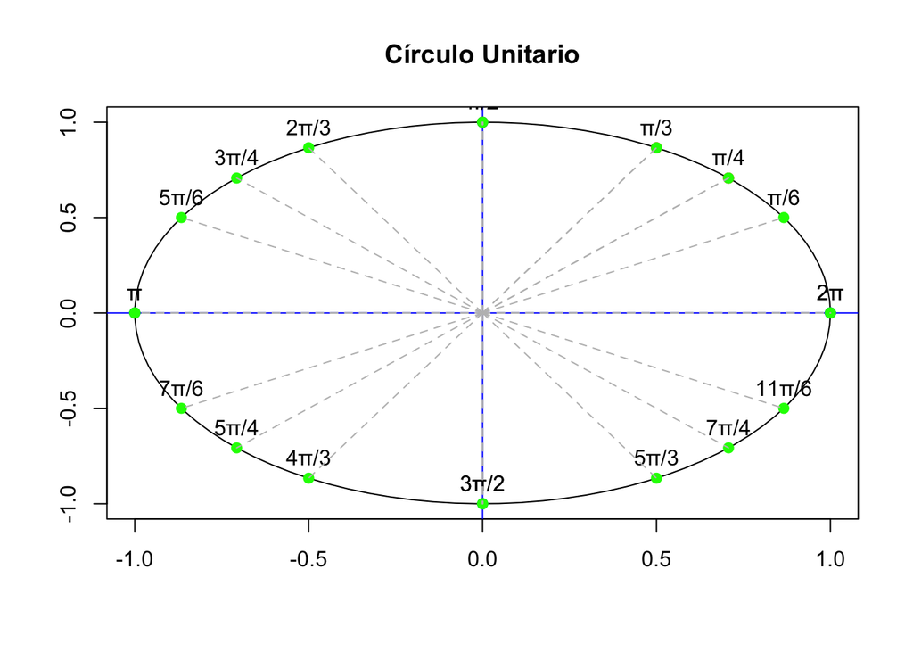

```r
# Generar puntos en el círculo unitario
theta <- seq(0, 2 * pi, length.out = 100) # Ángulos de 0 a 2*pi
x <- cos(theta) # Coordenada x
y <- sin(theta) # Coordenada y

# Ángulos específicos (π/4, π/2, π/3)
angles <- c(pi/4, pi/2, pi/3)

# Coordenadas de los puntos en la circunferencia para los ángulos específicos
x_points <- cos(angles)
y_points <- sin(angles)

# Valores de ángulos en términos de π
angle_labels <- c("π/4", "π/2", "π/3")

# Ángulos múltiplos de π/2 y π/3 hasta 2π
angles_multiples <- seq(0, 2 * pi, by = pi/2)
angles_multiples <- angles_multiples[angles_multiples <= 2 * pi]  # Asegurarse de que no exceda 2π

# Coordenadas de los puntos en la circunferencia para los ángulos múltiples
x_multiples <- cos(angles_multiples)
y_multiples <- sin(angles_multiples)

# Valores de ángulos múltiples en términos de π
angle_labels_multiples <- as.character(angles_multiples / pi)

# Ángulos adicionales (π/4, 2π/4, 3π/4, 4π/4, 5π/4, 6π/4, 7π/4, 8π/4, π/3, 2π/3, 3π/3, 4π/3, 5π/3, 6π/3, 7π/3, 8π/3, 9π/3, 10π/3, 11π/3, 12π/3)
additional_angles <- c(pi/4, 2*pi/4, 3*pi/4, 4*pi/4, 5*pi/4, 6*pi/4, 7*pi/4, 8*pi/4,
                       pi/6, 2*pi/6, 3*pi/6, 4*pi/6, 5*pi/6, 6*pi/6, 7*pi/6, 8*pi/6,
                       9*pi/6, 10*pi/6, 11*pi/6, 12*pi/6)



# Coordenadas de los puntos en la circunferencia para los ángulos adicionales
x_additional <- cos(additional_angles)
y_additional <- sin(additional_angles)

# Valores de ángulos adicionales en términos de π
#angle_labels_additional <- c(pi/4, 2*pi/4, 3*pi/4, 4*pi/4, 5*pi/4, 6*pi/4, 7*pi/4, 8*pi/4,
#                             pi/3, 2*pi/3, 3*pi/3, 4*pi/3, 5*pi/3, 6*pi/3, 7*pi/3, 8*pi/3,
#                             9*pi/3, 10*pi/3, 11*pi/3, 12*pi/3)

angle_labels_additional <- c("π/4", "π/2", "3π/4", "π", "5π/4", "3π/2",
                             "7π/4", "2π", "π/6", "π/3", "π/2", "2π/3",
                             "5π/6", "π", "7π/6", "4π/3", "3π/2", "5π/3",
                             "11π/6", "2π")


# Graficar el círculo unitario
plot(x, y, type = "n", aspect = 1, xlim = c(-1, 1), ylim = c(-1, 1),
     xlab = "", ylab = "", main = "Círculo Unitario")
# Dibujar los ejes X y Y en color azul y grosor delgado
abline(h = 0, col = "blue", lwd = 1) # Eje X
abline(v = 0, col = "blue", lwd = 1) # Eje Y

# Dibujar el círculo unitario
lines(x, y)

# Agregar puntos en la circunferencia para ángulos específicos
points(x_points, y_points, pch = 19, col = "red")

# Etiquetar los puntos con los valores de ángulo en términos de π
#text(x_points, y_points, labels = angle_labels, pos = 3)

# Agregar puntos en la circunferencia para ángulos múltiples
points(x_multiples, y_multiples, pch = 19, col = "blue")

# Etiquetar los puntos con los valores de ángulo múltiples en términos de π
#text(x_multiples, y_multiples, labels = angle_labels_multiples, pos = 3)

# Agregar puntos en la circunferencia para ángulos adicionales
points(x_additional, y_additional, pch = 19, col = "green")

# Etiquetar los puntos con los valores de ángulo adicionales en términos de π
text(x_additional, y_additional, labels = angle_labels_additional, pos = 3)

# Agregar líneas punteadas desde (0,0) a los puntos sobre la circunferencia
segments(0, 0, x_points, y_points, col = "gray", lty = 2)
segments(0, 0, x_multiples, y_multiples, col = "gray", lty = 2)
segments(0, 0, x_additional, y_additional, col = "gray", lty = 2)
```

### Función $sen(x)$

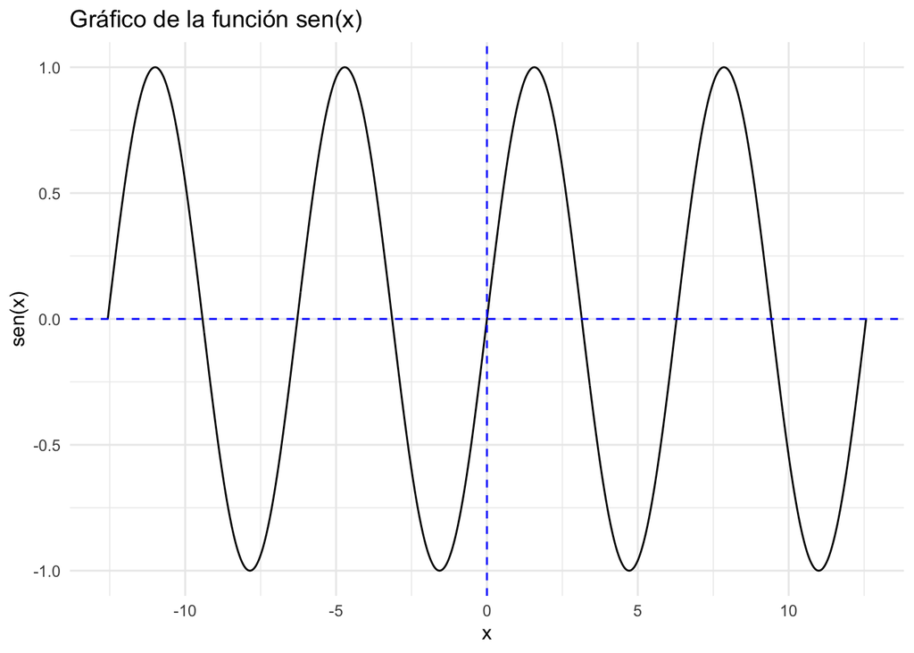

```r
# Define el intervalo y la cantidad de puntos
t <- 2  # Puedes ajustar este valor según tus necesidades
x <- seq(-2 * pi * t, 2 * pi * t, length.out = 1000)  # Intervalo y cantidad de puntos

# Calcula los valores de sen(x)
y <- sin(x)

# Crea un dataframe para los datos
data <- data.frame(x = x, y = y)

# Crea el gráfico usando ggplot2
ggplot(data, aes(x = x, y = y)) +
  geom_line() +
  geom_hline(yintercept = 0, linetype = "dashed", color = "blue") +  # Eje X
  geom_vline(xintercept = 0, linetype = "dashed", color = "blue") +   # Eje Y
  labs(title = "Gráfico de la función sen(x)",
       x = "x",
       y = "sen(x)") +
  theme_minimal()
```

### Función $sen(hx)$

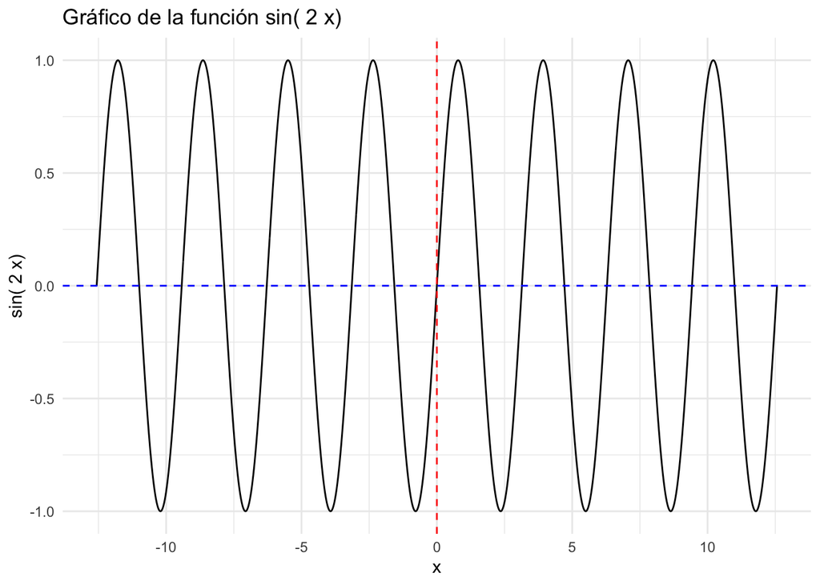

```r
# Define el intervalo y la cantidad de puntos
t <- 2  # Puedes ajustar este valor según tus necesidades
h <- 2  # Ajusta el valor de h según tus necesidades
x <- seq(-2 * pi * t, 2 * pi * t, length.out = 1000)  # Intervalo y cantidad de puntos

# Calcula los valores de sin(hx)
y <- sin(h * x)

# Crea un dataframe para los datos
data <- data.frame(x = x, y = y)

# Crea el gráfico usando ggplot2
ggplot(data, aes(x = x, y = y)) +
  geom_line() +
  geom_hline(yintercept = 0, linetype = "dashed", color = "blue") +  # Eje X
  geom_vline(xintercept = 0, linetype = "dashed", color = "red") +   # Eje Y
  labs(title = paste("Gráfico de la función sin(", h, "x)"),
       x = "x",
       y = paste("sin(", h, "x)")) +
  theme_minimal()
```

### Función $sen(hx+r)$

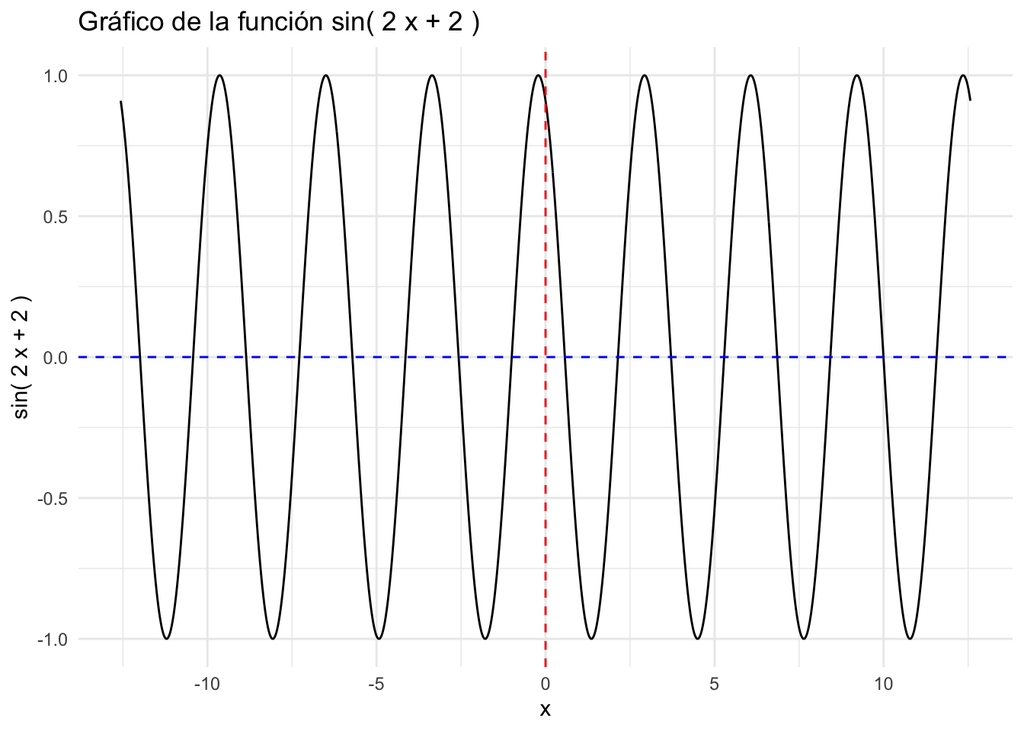

```r
# Define el intervalo y la cantidad de puntos
t <- 2  # Puedes ajustar este valor según tus necesidades
h <- 2  # Ajusta el valor de h según tus necesidades
r <- 2  # Ajusta el valor de r según tus necesidades
x <- seq(-2 * pi * t, 2 * pi * t, length.out = 1000)  # Intervalo y cantidad de puntos

# Calcula los valores de sin(hx + r)
y <- sin(h * x + r)

# Crea un dataframe para los datos
data <- data.frame(x = x, y = y)

# Crea el gráfico usando ggplot2
ggplot(data, aes(x = x, y = y)) +
  geom_line() +
  geom_hline(yintercept = 0, linetype = "dashed", color = "blue") +  # Eje X
  geom_vline(xintercept = 0, linetype = "dashed", color = "red") +   # Eje Y
  labs(title = paste("Gráfico de la función sin(", h, "x +", r, ")"),
       x = "x",
       y = paste("sin(", h, "x +", r, ")")) +
  theme_minimal()
```

### Función $k*sen(hx+r)$

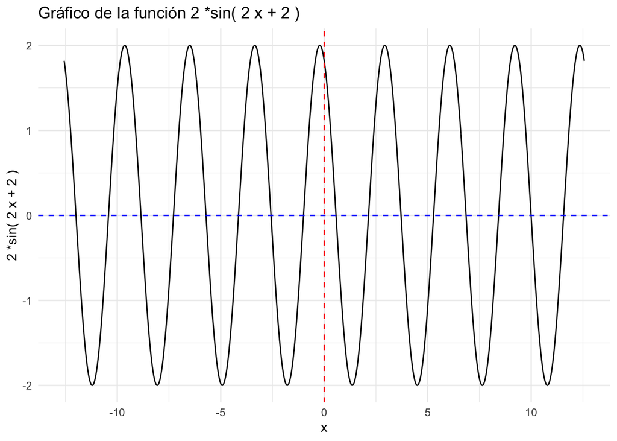

```r
# Define el intervalo y la cantidad de puntos
t <- 2  # Puedes ajustar este valor según tus necesidades
h <- 2  # Ajusta el valor de h según tus necesidades
r <- 2  # Ajusta el valor de r según tus necesidades
k <- 2  # Ajusta el valor de k según tus necesidades
x <- seq(-2 * pi * t, 2 * pi * t, length.out = 1000)  # Intervalo y cantidad de puntos

# Calcula los valores de k*sin(hx + r)
y <- k * sin(h * x + r)

# Crea un dataframe para los datos
data <- data.frame(x = x, y = y)

# Crea el gráfico usando ggplot2
ggplot(data, aes(x = x, y = y)) +
  geom_line() +
  geom_hline(yintercept = 0, linetype = "dashed", color = "blue") +  # Eje X
  geom_vline(xintercept = 0, linetype = "dashed", color = "red") +   # Eje Y
  labs(title = paste("Gráfico de la función", k, "*sin(", h, "x +", r, ")"),
       x = "x",
       y = paste(k, "*sin(", h, "x +", r, ")")) +
  theme_minimal()
```

### Función $s+k*sen(hx+r)$

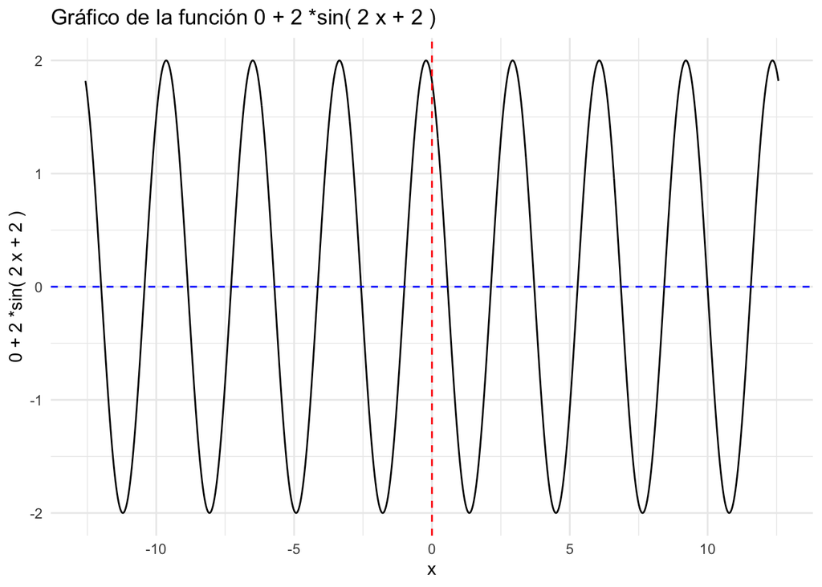

```r
# Define el intervalo y la cantidad de puntos
t <- 2  # Puedes ajustar este valor según tus necesidades
h <- 2  # Ajusta el valor de h según tus necesidades
r <- 2  # Ajusta el valor de r según tus necesidades
k <- 2  # Ajusta el valor de k según tus necesidades
s <- 0  # Ajusta el valor de s según tus necesidades
x <- seq(-2 * pi * t, 2 * pi * t, length.out = 1000)  # Intervalo y cantidad de puntos

# Calcula los valores de s + k*sin(hx + r)
y <- s + k * sin(h * x + r)

# Crea un dataframe para los datos
data <- data.frame(x = x, y = y)

# Crea el gráfico usando ggplot2
ggplot(data, aes(x = x, y = y)) +
  geom_line() +
  geom_hline(yintercept = 0, linetype = "dashed", color = "blue") +  # Eje X
  geom_vline(xintercept = 0, linetype = "dashed", color = "red") +   # Eje Y
  labs(title = paste("Gráfico de la función", s, "+", k, "*sin(", h, "x +", r, ")"),
       x = "x",
       y = paste(s, "+", k, "*sin(", h, "x +", r, ")")) +
  theme_minimal()
```

### Función $cos(x)$

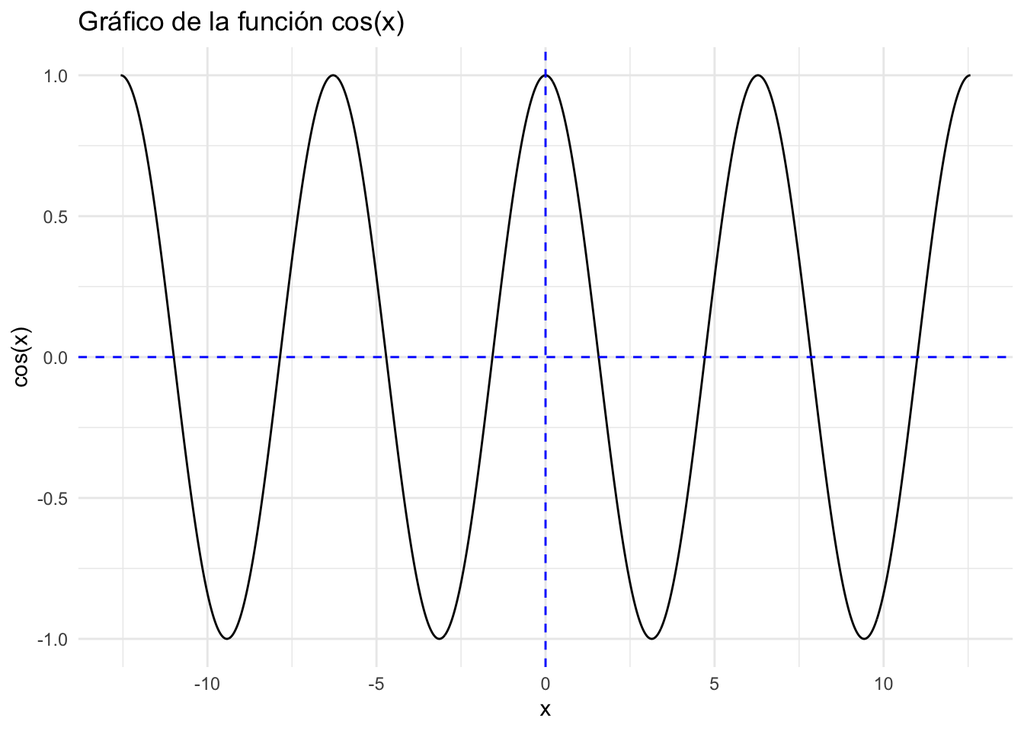

```r
# Define el intervalo y la cantidad de puntos
t <- 2  # Puedes ajustar este valor según tus necesidades
x <- seq(-2 * pi * t, 2 * pi * t, length.out = 1000)  # Intervalo y cantidad de puntos

# Calcula los valores de sen(x)
y <- cos(x)

# Crea un dataframe para los datos
data <- data.frame(x = x, y = y)

# Crea el gráfico usando ggplot2
ggplot(data, aes(x = x, y = y)) +
  geom_line() +
  geom_hline(yintercept = 0, linetype = "dashed", color = "blue") +  # Eje X
  geom_vline(xintercept = 0, linetype = "dashed", color = "blue") +   # Eje Y
  labs(title = "Gráfico de la función cos(x)",
       x = "x",
       y = "cos(x)") +
  theme_minimal()
```

### Función $cos(hx)$

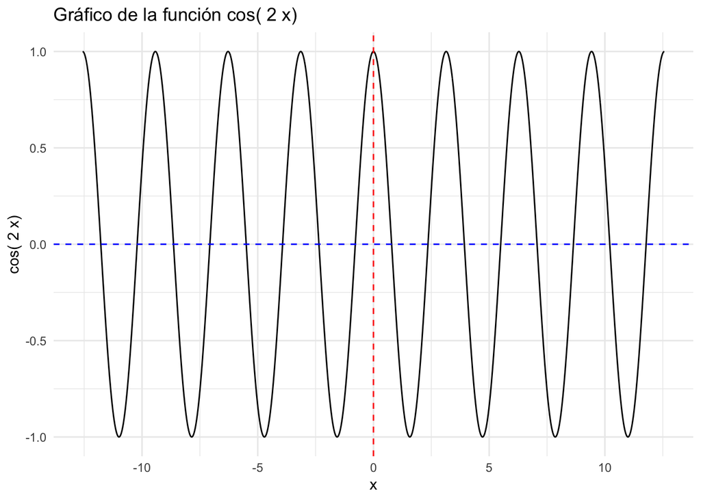

```r
# Define el intervalo y la cantidad de puntos
t <- 2  # Puedes ajustar este valor según tus necesidades
h <- 2  # Ajusta el valor de h según tus necesidades
x <- seq(-2 * pi * t, 2 * pi * t, length.out = 1000)  # Intervalo y cantidad de puntos

# Calcula los valores de cos(hx)
y <- cos(h * x)

# Crea un dataframe para los datos
data <- data.frame(x = x, y = y)

# Crea el gráfico usando ggplot2
ggplot(data, aes(x = x, y = y)) +
  geom_line() +
  geom_hline(yintercept = 0, linetype = "dashed", color = "blue") +  # Eje X
  geom_vline(xintercept = 0, linetype = "dashed", color = "red") +   # Eje Y
  labs(title = paste("Gráfico de la función cos(", h, "x)"),
       x = "x",
       y = paste("cos(", h, "x)")) +
  theme_minimal()
```

### Función $cos(hx+r)$

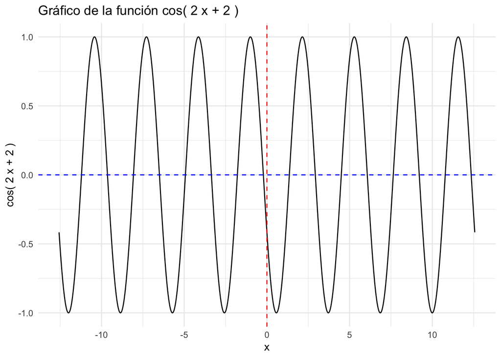

```r
# Define el intervalo y la cantidad de puntos
t <- 2  # Puedes ajustar este valor según tus necesidades
h <- 2  # Ajusta el valor de h según tus necesidades
r <- 2  # Ajusta el valor de r según tus necesidades
x <- seq(-2 * pi * t, 2 * pi * t, length.out = 1000)  # Intervalo y cantidad de puntos

# Calcula los valores de cos(hx + r)
y <- cos(h * x + r)

# Crea un dataframe para los datos
data <- data.frame(x = x, y = y)

# Crea el gráfico usando ggplot2
ggplot(data, aes(x = x, y = y)) +
  geom_line() +
  geom_hline(yintercept = 0, linetype = "dashed", color = "blue") +  # Eje X
  geom_vline(xintercept = 0, linetype = "dashed", color = "red") +   # Eje Y
  labs(title = paste("Gráfico de la función cos(", h, "x +", r, ")"),
       x = "x",
       y = paste("cos(", h, "x +", r, ")")) +
  theme_minimal()
```

### Función $k*cos(hx+r)$

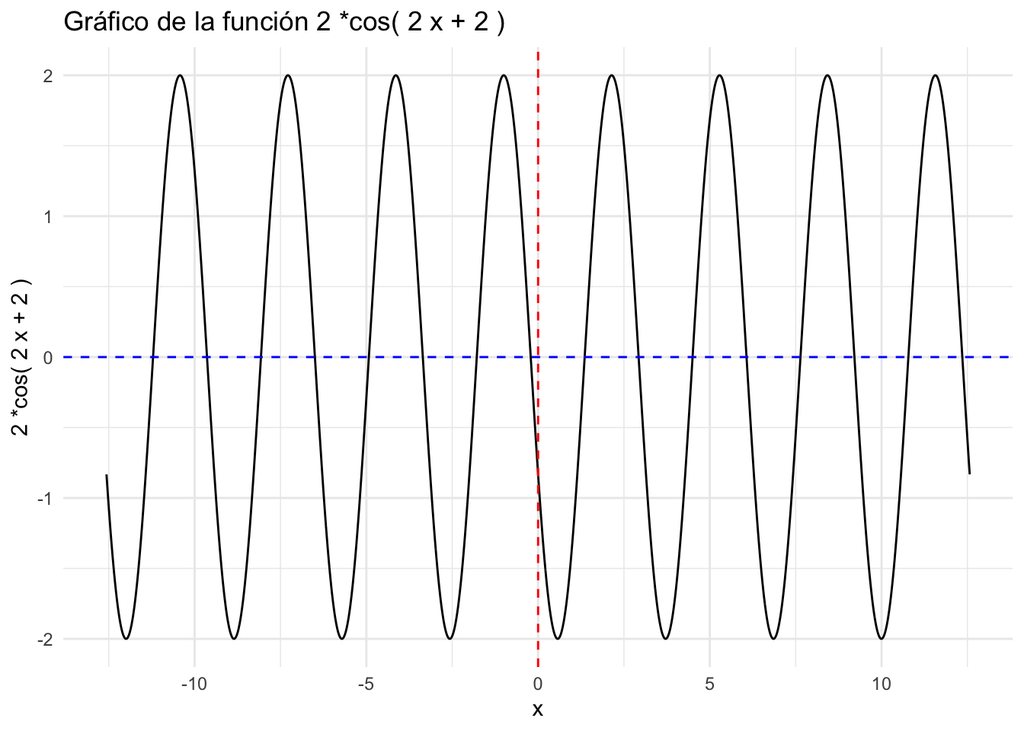

```r
# Define el intervalo y la cantidad de puntos
t <- 2  # Puedes ajustar este valor según tus necesidades
h <- 2  # Ajusta el valor de h según tus necesidades
r <- 2  # Ajusta el valor de r según tus necesidades
k <- 2  # Ajusta el valor de k según tus necesidades
x <- seq(-2 * pi * t, 2 * pi * t, length.out = 1000)  # Intervalo y cantidad de puntos

# Calcula los valores de k*cos(hx + r)
y <- k * cos(h * x + r)

# Crea un dataframe para los datos
data <- data.frame(x = x, y = y)

# Crea el gráfico usando ggplot2
ggplot(data, aes(x = x, y = y)) +
  geom_line() +
  geom_hline(yintercept = 0, linetype = "dashed", color = "blue") +  # Eje X
  geom_vline(xintercept = 0, linetype = "dashed", color = "red") +   # Eje Y
  labs(title = paste("Gráfico de la función", k, "*cos(", h, "x +", r, ")"),
       x = "x",
       y = paste(k, "*cos(", h, "x +", r, ")")) +
  theme_minimal()
```

### Función $s+k*cos(hx+r)$

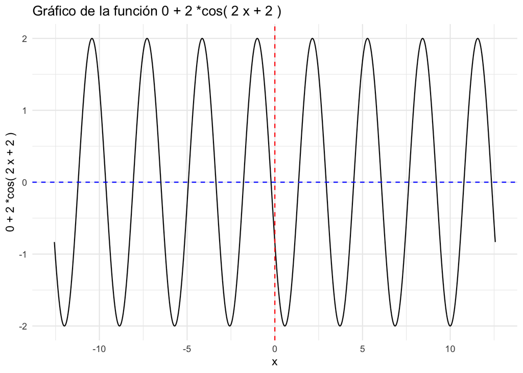

```r
# Define el intervalo y la cantidad de puntos
t <- 2  # Puedes ajustar este valor según tus necesidades
h <- 2  # Ajusta el valor de h según tus necesidades
r <- 2  # Ajusta el valor de r según tus necesidades
k <- 2  # Ajusta el valor de k según tus necesidades
s <- 0  # Ajusta el valor de s según tus necesidades
x <- seq(-2 * pi * t, 2 * pi * t, length.out = 1000)  # Intervalo y cantidad de puntos

# Calcula los valores de s + k*cos(hx + r)
y <- s + k * cos(h * x + r)

# Crea un dataframe para los datos
data <- data.frame(x = x, y = y)

# Crea el gráfico usando ggplot2
ggplot(data, aes(x = x, y = y)) +
  geom_line() +
  geom_hline(yintercept = 0, linetype = "dashed", color = "blue") +  # Eje X
  geom_vline(xintercept = 0, linetype = "dashed", color = "red") +   # Eje Y
  labs(title = paste("Gráfico de la función", s, "+", k, "*cos(", h, "x +", r, ")"),
       x = "x",
       y = paste(s, "+", k, "*cos(", h, "x +", r, ")")) +
  theme_minimal()
```

### Función $tan(x)$

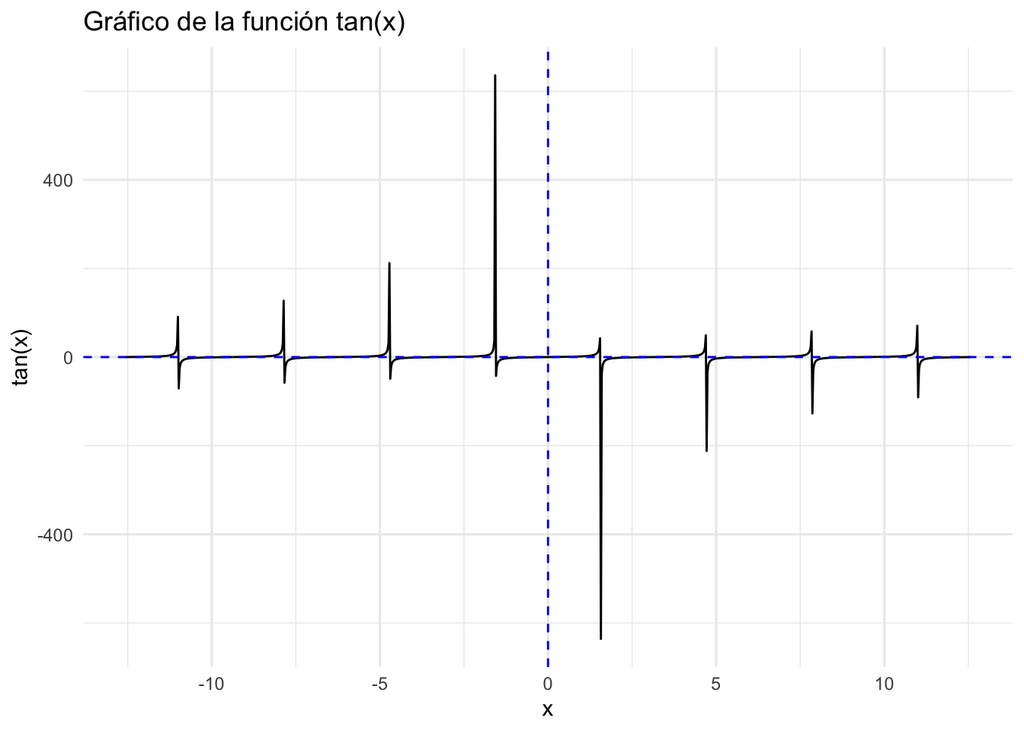

```r
# Define el intervalo y la cantidad de puntos
t <- 2  # Puedes ajustar este valor según tus necesidades
x <- seq(-2 * pi * t, 2 * pi * t, length.out = 1000)  # Intervalo y cantidad de puntos

# Calcula los valores de sen(x)
y <- tan(x)

# Crea un dataframe para los datos
data <- data.frame(x = x, y = y)

# Crea el gráfico usando ggplot2
ggplot(data, aes(x = x, y = y)) +
  geom_line() +
  geom_hline(yintercept = 0, linetype = "dashed", color = "blue") +  # Eje X
  geom_vline(xintercept = 0, linetype = "dashed", color = "blue") +   # Eje Y
  labs(title = "Gráfico de la función tan(x)",
       x = "x",
       y = "tan(x)") +
  theme_minimal()
```

### Función $tan(hx)$

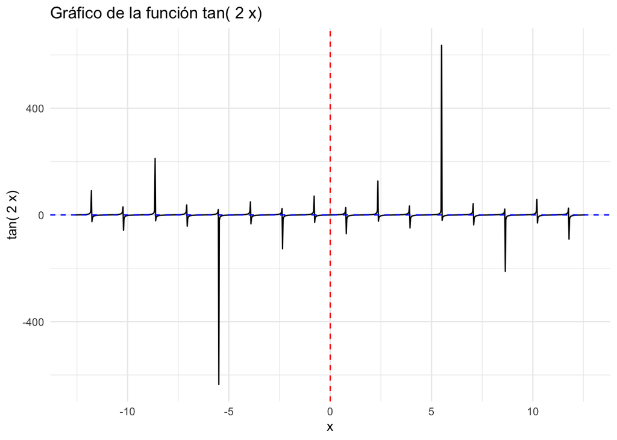

```r
# Define el intervalo y la cantidad de puntos
t <- 2  # Puedes ajustar este valor según tus necesidades
h <- 2  # Ajusta el valor de h según tus necesidades
x <- seq(-2 * pi * t, 2 * pi * t, length.out = 1000)  # Intervalo y cantidad de puntos

# Calcula los valores de tan(hx)
y <- tan(h * x)

# Crea un dataframe para los datos
data <- data.frame(x = x, y = y)

# Crea el gráfico usando ggplot2
ggplot(data, aes(x = x, y = y)) +
  geom_line() +
  geom_hline(yintercept = 0, linetype = "dashed", color = "blue") +  # Eje X
  geom_vline(xintercept = 0, linetype = "dashed", color = "red") +   # Eje Y
  labs(title = paste("Gráfico de la función tan(", h, "x)"),
       x = "x",
       y = paste("tan(", h, "x)")) +
  theme_minimal()
```

### Función $tan(hx+r)$

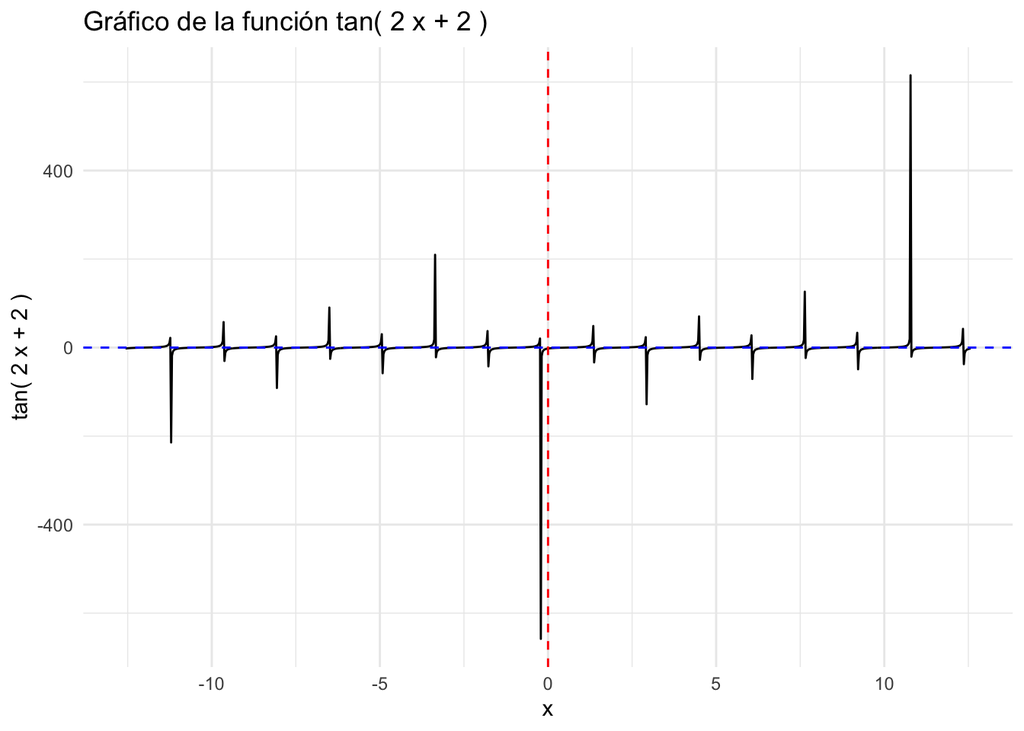

```r
# Define el intervalo y la cantidad de puntos
t <- 2  # Puedes ajustar este valor según tus necesidades
h <- 2  # Ajusta el valor de h según tus necesidades
r <- 2  # Ajusta el valor de r según tus necesidades
x <- seq(-2 * pi * t, 2 * pi * t, length.out = 1000)  # Intervalo y cantidad de puntos

# Calcula los valores de tan(hx + r)
y <- tan(h * x + r)

# Crea un dataframe para los datos
data <- data.frame(x = x, y = y)

# Crea el gráfico usando ggplot2
ggplot(data, aes(x = x, y = y)) +
  geom_line() +
  geom_hline(yintercept = 0, linetype = "dashed", color = "blue") +  # Eje X
  geom_vline(xintercept = 0, linetype = "dashed", color = "red") +   # Eje Y
  labs(title = paste("Gráfico de la función tan(", h, "x +", r, ")"),
       x = "x",
       y = paste("tan(", h, "x +", r, ")")) +
  theme_minimal()
```

### Función $k*tan(hx+r)$

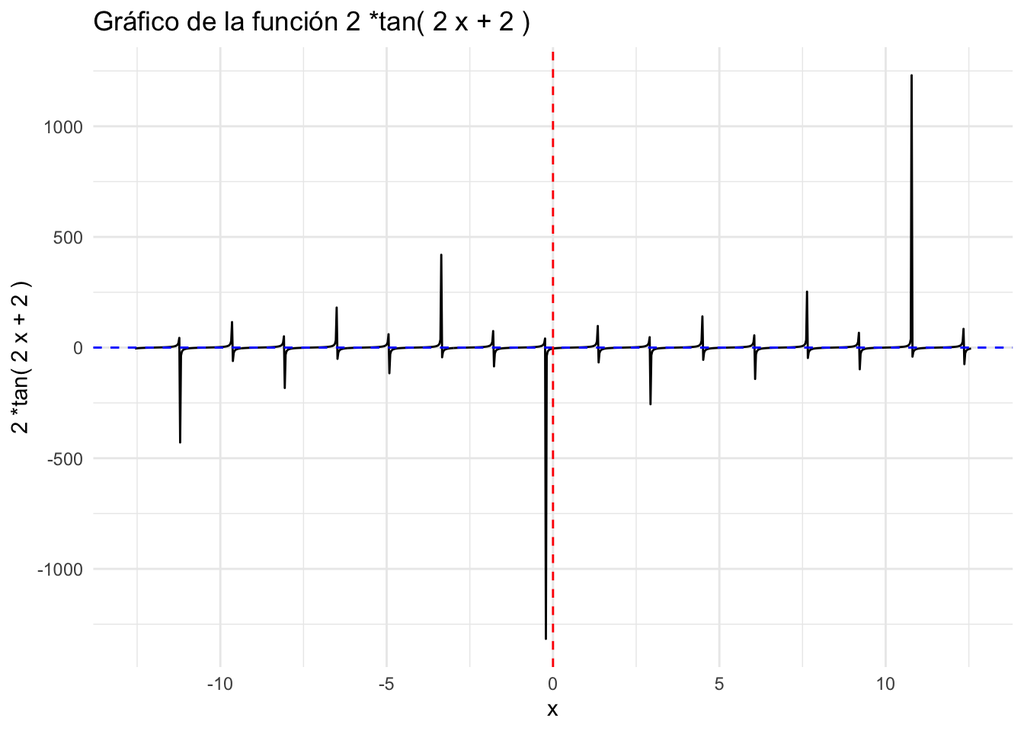

```r
# Define el intervalo y la cantidad de puntos
t <- 2  # Puedes ajustar este valor según tus necesidades
h <- 2  # Ajusta el valor de h según tus necesidades
r <- 2  # Ajusta el valor de r según tus necesidades
k <- 2  # Ajusta el valor de k según tus necesidades
x <- seq(-2 * pi * t, 2 * pi * t, length.out = 1000)  # Intervalo y cantidad de puntos

# Calcula los valores de k*tan(hx + r)
y <- k * tan(h * x + r)

# Crea un dataframe para los datos
data <- data.frame(x = x, y = y)

# Crea el gráfico usando ggplot2
ggplot(data, aes(x = x, y = y)) +
  geom_line() +
  geom_hline(yintercept = 0, linetype = "dashed", color = "blue") +  # Eje X
  geom_vline(xintercept = 0, linetype = "dashed", color = "red") +   # Eje Y
  labs(title = paste("Gráfico de la función", k, "*tan(", h, "x +", r, ")"),
       x = "x",
       y = paste(k, "*tan(", h, "x +", r, ")")) +
  theme_minimal()
```

### Función $s+k*tan(hx+r)$

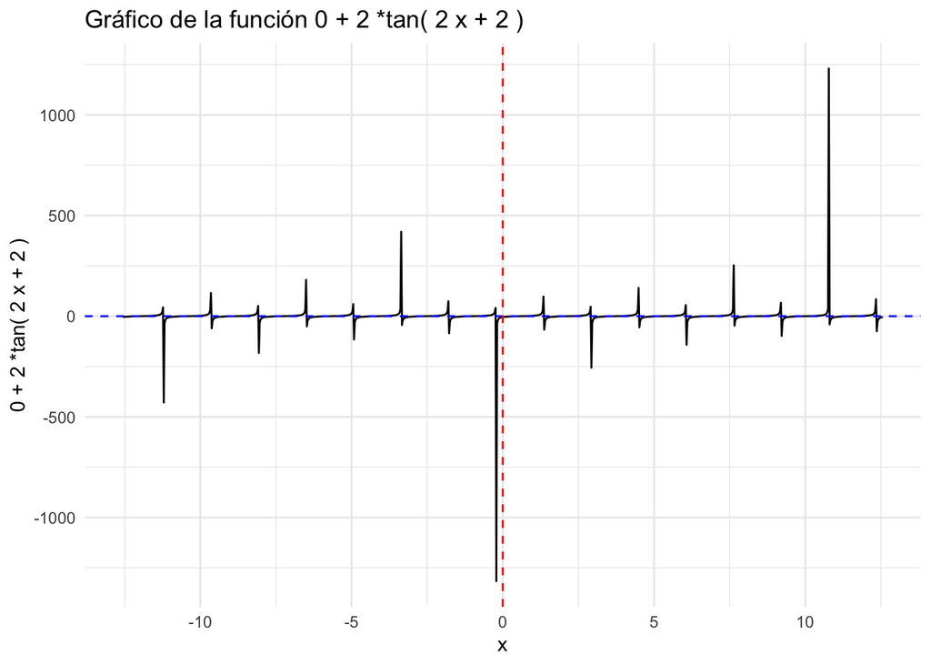

```r
# Define el intervalo y la cantidad de puntos
t <- 2  # Puedes ajustar este valor según tus necesidades
h <- 2  # Ajusta el valor de h según tus necesidades
r <- 2  # Ajusta el valor de r según tus necesidades
k <- 2  # Ajusta el valor de k según tus necesidades
s <- 0  # Ajusta el valor de s según tus necesidades
x <- seq(-2 * pi * t, 2 * pi * t, length.out = 1000)  # Intervalo y cantidad de puntos

# Calcula los valores de s + k*tan(hx + r)
y <- s + k * tan(h * x + r)

# Crea un dataframe para los datos
data <- data.frame(x = x, y = y)

# Crea el gráfico usando ggplot2
ggplot(data, aes(x = x, y = y)) +
  geom_line() +
  geom_hline(yintercept = 0, linetype = "dashed", color = "blue") +  # Eje X
  geom_vline(xintercept = 0, linetype = "dashed", color = "red") +   # Eje Y
  labs(title = paste("Gráfico de la función", s, "+", k, "*tan(", h, "x +", r, ")"),
       x = "x",
       y = paste(s, "+", k, "*tan(", h, "x +", r, ")")) +
  theme_minimal()
```